# PLM_Data_Exploration_USDCETH_1%_v1

```python
import os
import numpy as np
import math
from scipy import integrate
import scipy.stats as st
import pandas as pd
import matplotlib.pyplot as plt
from datetime import datetime,timedelta
import seaborn as sns
import statsmodels.api as sm
import scipy.stats as stats
from tqdm import tqdm
```

- 0 数据预处理
- 1 基于position的分析  
  含本金、时间间隔、累计收益、transaction cost、fee earned、wealth change、价格区间宽度分析
- 2 基于LP的分析

本文档结论主要有：

1. 年化较高的position特点
- fee earned年化更高
- wealth change基本为正值
- 持有时间短（基本短于2天）
- transaction cost总额区别不大,但年化小
- 价格区间相对较窄
1. 年化收益率高的LP特点
- fee earned年化相对更高
- transaction cost总额区别不大,但年化小
- 大部分参与时间短于2周
- wealth change为正

Note:

- This file is used to help convert the values in the block-chain (as shown in the original table) to the true and meaningful values in the real world, so that it can be used in the data analysis.
- Let $Value_{chain}$ denote the value in chain and $Value_{real}$ denote the value in the real world.
- ### event_name:
  - Mint: add liquidity and deposit tokens
  - Burn: remove liquidity. Generally one burn is followed by one collect, and when 2 burn is followed by one collect, the second burn is to delete the token address from NFT Manager.
  - Collect: collect fee earned and the remaining principal when the burn action is implemented. (transaction cost is paid separately)
  - Swap: exchange one token for another
- ### Timestamp (seconds): Unix style timestamp. $t_{chain} = 31556926*t_{year}+ 2629743*t_{month}+86400*c+3600*t_{hour}+60*t_{min}+t_{sec}$ $t_{real}=t_{year}+1970,t_{month},t_{day},t_{hour},t_{min},t_{sec}$
- ### gasUsed: The total gas that is consumed by the transaction.

  $$value_{chain}=value_{real}$$
- ### gasPrice: The gas price at the historical moment. $$G_{chain}=63800000000,G_{real}=G_{chain}\times 10^{-9}=63.8Gwei,$$

  ( $1 Ether = 10^9 Gwei = 10^{18} Wei$)
- ### transactionCost: The total transaction cost = gasUsed $\times$ gasPrice.

  $$Tcost_{chain}=324102341200000000Wei= 0.3241023412ETH \times 10^{18}$$
- ### tickSpacing: The amount of required tick separation, realized in multiples of tickSpacing e.g., a tickSpacing of 3 requires ticks to be initialized every 3rd tick i.e., ..., -6, -3, 0, 3, 6, ...
- ### fee tier:0.05%, 0.30%, and 1% $$t_{chain}=3000=0.3\%* 10^{6}$$
- ### Tick converted to price: Token 0 is USDC, Token 1 is ETH $$Price=\frac{T_1}{T_0}$$

  $$P_{chain}= 1.0001^{tick}=P_{real}\times 10^{12}$$
- ### Price converted to tick: Token 0 is USDC, Token 1 is ETH

  $P_{chain}$ is in type of sqrtPriceX96. $$P_{chain}=\sqrt{1.0001^{tick}}\times 2^{96}$$ $$Tick=\lfloor \log_{1.0001}(P_{chain}/2^{96})\times 2\rfloor$$
- ### amount0_delta/amount1_delta:
  - for swap: the delta of token balance of the pool
  - for mint: how much token was required for the minted liquidity
  - for burn: The amount of token withdrawn

  $USDC: \Delta T_{0}^{chain}=50000000000=50000\times 10^6=\Delta T_0^{real }\times 10^6$

  $ETH: \Delta T_{1}^{chain} =9.20548411925653\times 10^{18}=\Delta T_1^{real}\times 10^{18}$
- ### liquidity: The virtual liquidity of the pool after swap. $$L_{chain}=L_{real}\times 10^{12}$$
- ### liquidity_delta: The amount of liquidity to be removed or added.

$$\Delta L_{chain}=\Delta L_{real}\times 10^{12}$$$$\Delta T_0=L (\frac{1}{\sqrt{P_{current}}}-\frac{1}{\sqrt{P_{upper}}})$$$$\Delta T_1=L(\sqrt{P_{current}}-\sqrt{P_{lower}})$$

- ### Original file columns

| Column Name | Description |
| --- | --- |
| txn_hash | Transaction hash, it is used to uniquely identify each transaction. |
| timestamp | Unix style timestamp. Conversion tool: https://www.unixtimestamp.com/index.php. |
| gasUsed | The total gas that is consumed by the transaction. [Unit: Wei] |
| gasPrice | The gas price at the historical moment. [Unit: Wei] |
| transaction_cost | The total transaction cost. transaction_cost = gasUsed x gasPrice. [Unit: Wei x Wei] |
| tokenId | The ID of the non-fungible token, representing a unique position range (a combination of "tickerLower" and "tickUpper") |
| tickLower | The lower boundary of the position range. Actual lower price boundary = 1.0001^tickLower/10^12. |
| tickUpper | The upper boundary of the position range. Actual upper price boundary = 1.0001^tickUpper}/10^12. |
| amount0 | The amount of fee collected from token 0 (base currency) by the Collect Event. |
| amount1 | The amount of fee collected from token 1 (quote currency) by the Collect Event. |
| liquidity | The liquidity of the pool after the transaction. Liquidity = sqrt(amount of token 0 x amount of token 1) |
| paid0 | The amount of token 0 paid for the "Flash Swap". |
| paid1 | The amount of token 1 paid for the "Flash Swap". |
| amount0_delta | The change of the amount of token 0. |
| amount1_delta | The change of the amount of token 1. |
| liquidity_delta | The change of the liquidity of the pool. |
| sqrtPriceX96 | The ratio of sqrt(amount of token 1 / amount of token 0).The relationship of sqrtPriceX96 and tick is: `1.0001 ^ (tick / 2) x 2 ^ 96 = sqrtPriceX96.` |
| tick | Representing the price. Actual price = 1.0001 ^ tick. |
| event_type | Possible values: "AddLiquidity", "RemoveLiquidity", "Swap", "Flash". "Flash" will be integrated to "Swap" later. |
| from | For mint, collect and burn, the from address is the address of the liquidity provider. |

- ### Columns added by data pre-processing |Column Name|Description| |:---|:---| |dt|by action时间差，e.g.从burn到burn的时间(second)| |p_current|当前价格| |p_previous|前一时刻价格| |price_change|p_current-p_previous| |burn_dt|burn到该position上一mint时间差| |fee_earned_token0|以token0记录的手续费| |fee_earned_token1|以token1记录的手续费| |burn_value_usdc|该burn在burn时的wealth| |mint_value_usdc|该mint在mint时的wealth| |fee_earned_usdc|该collect action总手续费(USD)| |transaction_cost_usdc|该action交易费用(USD)| |wealth|以action时价格记的action导致的池中wealth变化| |cum_wealth|by position wealth累计值| |cum_liquidity|by position liquidity累计值| |outbound_flag|是否有mint时price不在所设定的区间内的，是则为True| |center_deviation|position的中点偏离mint时价格占position宽度的比例| |tick_range|该position宽度，`tick_range = tickUpper - tickLower`|

```python
file = 'USDC_ETH_10000_0x7BeA39867e4169DBe237d55C8242a8f2fcDcc387_0_8976_transaction_event_log.csv'
indir = r'D:\Documents\21 Spring\PLM\Transaction_data0727'
file_2 = 'USDCETH_10000_0809.csv'
# 'USDC_ETH_500_0807.csv'
'''
Transaction columns - original file
['timeStamp', 'blockNumber', 'transactionIndex', 'transactionHash',
       'from', 'to', 'gasPrice', 'gasUsed', 'transactionCost', 'type',
       'status', 'token0Address', 'token1Address', 'tickSpacing', 'feeTier',
       'token0Decimal', 'token1Decimal', 'sender', 'owner', 'recipient',
       'tickLower', 'tickUpper', 'amount0', 'amount1', 'liquidity',
       'amount0_delta', 'amount1_delta', 'liquidity_delta',
       'amount0_collected', 'amount1_collected', 'amount0_flashed',
       'amount1_flashed', 'paid0', 'paid1', 'sqrtPriceX96', 'tick',
       'event_name']

Columns added by data pre-processing
['transaction_cost', 'burn_value_usdc','mint_value_usdc', 'price_impact_usdc', 'fee_earned_usdc',
'transaction_cost_usdc', 'pnl']

Event type: ['Burn', 'Collect', 'Initialize', 'Mint', 'Swap']

'''
col_name = ['transactionCost','gasPrice', 'gasUsed', 'amount0_delta',
        'amount1_delta', 'liquidity_delta','amount0_collected', 'amount1_collected','tick',
        'event_name','owner']
info = ['from','tickUpper','tickLower'] # for position identification
```

# 0 数据预处理

```python
transaction = pd.read_csv(indir+'\\'+file, encoding = 'utf-8',low_memory=False)
transaction['transactionCost'] = transaction['transactionCost'].apply(lambda x:int(x)/10**18)
transaction['liquidity_delta'] = transaction['liquidity_delta'].apply(lambda x:float(x)/10**12)
transaction['amount1_delta'] = transaction['amount1_delta'].apply(lambda x:float(x)/10**18)
transaction['amount1_collected'] = transaction['amount1_collected'].apply(lambda x:float(x)/10**18)
mint = transaction[transaction['event_name']=='Mint'].index
burn = transaction[transaction['event_name']=='Burn'].index
collect = transaction[transaction['event_name']=='Collect'].index
swap = transaction[transaction['event_name']=='Swap'].index
transaction['dt'] = np.nan
transaction.loc[mint,'dt'] = transaction.loc[mint,'timeStamp'].diff()
transaction.loc[burn,'dt'] = transaction.loc[burn,'timeStamp'].diff()
transaction.loc[collect,'dt'] = transaction.loc[collect,'timeStamp'].diff()
transaction.loc[swap,'dt'] = transaction.loc[swap,'timeStamp'].diff()
transaction.loc[:,'tick'].ffill(inplace=True)
transaction['p_current'] = transaction['sqrtPriceX96'].apply(lambda x:math.log(float(x)/2**96,1.0001)*2)
transaction['p_current'].ffill(inplace=True)
transaction['burn_dt'] = np.nan
transaction['fee_earned_token0'] = np.nan
transaction['fee_earned_token1'] = np.nan
transaction['transaction_cost'] = np.nan
key_info = ['from','tickLower', 'tickUpper']

for co in tqdm(collect):
    flag = 0
    if transaction.loc[co-1,'event_name']=='Burn':
        if transaction.loc[co-2,'event_name']=='Burn':
            flag=1
        transaction.loc[co,'fee_earned_token1'] = transaction.loc[co,'amount1_collected'] + transaction.loc[co-1-flag,'amount1_delta']
        transaction.loc[co,'fee_earned_token0'] = transaction.loc[co,'amount0_collected'] + transaction.loc[co-1-flag,'amount0_delta']
    else:
        continue
    possible_mi = transaction.loc[mint,:].loc[(transaction.loc[co,key_info]==transaction.loc[mint,key_info]).sum(axis=1)==3].index
    possible_mi = possible_mi[possible_mi<co]
    possible_b = transaction.loc[burn,:].loc[(transaction.loc[co,key_info]==transaction.loc[burn,key_info]).sum(axis=1)==3].index
    possible_b = possible_b[possible_b<co]
    if possible_mi.empty:
        continue
    mi = max(possible_mi)
    transaction.loc[co,'burn_dt'] = transaction.loc[co,'timeStamp'] - transaction.loc[mi,'timeStamp']
transaction.loc[burn,'burn_value_usdc'] = (transaction.loc[burn,'amount0_delta']/10**6 + transaction.loc[burn,'amount1_delta']/(1.0001**transaction.loc[burn,'p_current']/10**12))
transaction.loc[mint,'mint_value_usdc'] = (transaction.loc[mint,'amount0_delta']/10**6 + transaction.loc[mint,'amount1_delta']/(1.0001**transaction.loc[mint,'p_current']/10**12))
transaction.loc[collect,'fee_earned_usdc'] = transaction.loc[collect,'fee_earned_token1']/(1.0001**transaction.loc[collect,'p_current']/10**12) + transaction.loc[collect,'fee_earned_token0']/10**6
transaction['wealth'] = transaction['amount0_delta']/10**6 +transaction['amount1_delta']/(1.0001**transaction['p_current']/10**12)
transaction.loc[swap,'wealth'] = 0
transaction.loc[collect,'wealth'] = 0
transaction['cum_wealth'] = transaction.groupby(info)['wealth'].cumsum()
transaction['liquidity_delta'].fillna(0,inplace=True)
transaction['cum_liquidity'] = transaction.groupby(info)['liquidity_delta'].cumsum()
transaction.to_csv(indir+'\\'+file_2)
```

```python
transaction.groupby(['event_name'])['transactionCost'].describe().T
```

| event_name | Burn | Collect | Initialize | Mint | Swap |
| --- | --- | --- | --- | --- | --- |
| count | 645.000000 | 622.000000 | 1.000000 | 773.000000 | 7582.000000 |
| mean | 0.005854 | 0.005829 | 0.263074 | 0.014275 | 0.018245 |
| std | 0.007514 | 0.007564 | NaN | 0.017422 | 0.037743 |
| min | 0.000594 | 0.000594 | 0.263074 | 0.001116 | 0.000000 |
| 25% | 0.002377 | 0.002377 | 0.263074 | 0.005198 | 0.004320 |
| 50% | 0.003736 | 0.003678 | 0.263074 | 0.009363 | 0.008209 |
| 75% | 0.006205 | 0.006196 | 0.263074 | 0.017673 | 0.018351 |
| max | 0.092651 | 0.092651 | 0.263074 | 0.263074 | 1.580159 |

```python
transaction.loc[swap,'p_current'].diff().describe().to_frame('price_change').T
```

|  | count | mean | std | min | 25% | 50% | 75% | max |
| --- | --- | --- | --- | --- | --- | --- | --- | --- |
| price_change | 7581.0 | 0.826755 | 48.852865 | -767.45679 | -10.723711 | 0.236757 | 12.993813 | 783.935656 |

for all collect actions without burn action ahead, the amount collected is 0

```python
a = [_-1 for _ in collect]
delta = set(a) - set(burn)
b = [_+1 for _ in delta]
all(transaction.loc[b,['amount0_collected', 'amount1_collected']]==0)
```

```
True
```

```python
transaction = pd.read_csv(indir+'\\'+file_2,index_col=0)
print(transaction.shape)
swap_all = transaction[transaction['event_name']=='Swap'].index
transaction = transaction.loc[:swap_all[:int(len(swap_all)*0.8)][-1],:]
mint = transaction[transaction['event_name']=='Mint'].index
burn = transaction[transaction['event_name']=='Burn'].index
collect = transaction[transaction['event_name']=='Collect'].index
swap = transaction[transaction['event_name']=='Swap'].index
transaction['transaction_cost_usdc'] = transaction['transactionCost']/(1.0001**transaction['p_current']/10**12)
transaction['p_previous'] = transaction.shift(1)['p_current']
transaction['price_change'] = transaction['p_current']-transaction.shift(1)['p_current']
transaction.timeStamp = pd.to_datetime(transaction.timeStamp, unit='s')
transaction
```

```
(9623, 49)
```

|  | timeStamp | blockNumber | transactionIndex | transactionHash | from | to | gasPrice | gasUsed | transactionCost | type | ... | transaction_cost | burn_value_usdc | mint_value_usdc | fee_earned_usdc | wealth | cum_wealth | cum_liquidity | transaction_cost_usdc | p_previous | price_change |
| --- | --- | --- | --- | --- | --- | --- | --- | --- | --- | --- | --- | --- | --- | --- | --- | --- | --- | --- | --- | --- | --- |
| 0 | 2021-05-04 20:07:45 | 12369811 | 255 | 0x004cb88319b0678320cb0a04fab8003897f33c345576... | 0xF27696C8BCa7D54D696189085Ae1283f59342fA6 | 0x10A0847c2D170008dDCa7C3a688124f493630032 | 49000000000 | 5368857 | 0.263074 | 0x0 | ... | NaN | NaN | NaN | NaN | NaN | NaN | NaN | 893.437325 | NaN | NaN |
| 1 | 2021-05-04 20:07:45 | 12369811 | 255 | 0x004cb88319b0678320cb0a04fab8003897f33c345576... | 0xF27696C8BCa7D54D696189085Ae1283f59342fA6 | 0x10A0847c2D170008dDCa7C3a688124f493630032 | 49000000000 | 5368857 | 0.263074 | 0x0 | ... | NaN | NaN | 1947.575266 | NaN | 1947.575266 | 1947.575266 | 123.809465 | 893.437325 | 195016.000000 | 0.000000 |
| 2 | 2021-05-04 20:38:51 | 12369971 | 131 | 0x2d4763faa40fc2d6cdf7f8afeab5448c755ce3279085... | 0xDd0d6c26A03D6f6541471D44179F56D478f50f6B | 0xE592427A0AEce92De3Edee1F18E0157C05861564 | 44950000000 | 237023 | 0.010654 | 0x0 | ... | NaN | NaN | NaN | NaN | 0.000000 | NaN | NaN | 35.848274 | 195016.000000 | 92.985713 |
| 3 | 2021-05-04 20:46:53 | 12370013 | 161 | 0x22ddba6cc2ec54322db54132340e7b73bf30807e1692... | 0xDd0d6c26A03D6f6541471D44179F56D478f50f6B | 0xE592427A0AEce92De3Edee1F18E0157C05861564 | 58000000000 | 255413 | 0.014814 | 0x0 | ... | NaN | NaN | NaN | NaN | 0.000000 | NaN | NaN | 47.610787 | 195108.985713 | 458.552597 |
| 4 | 2021-05-04 21:24:32 | 12370189 | 107 | 0x79ce22cf42c24772cd3fe5875bea9bb38ffa55e34071... | 0xC148480A8EfF5e6885ab0Ac7905291DD11fd6499 | 0xC36442b4a4522E871399CD717aBDD847Ab11FE88 | 51000000000 | 451712 | 0.023037 | 0x0 | ... | NaN | NaN | 170.951522 | NaN | 170.951522 | 170.951522 | 13.358545 | 74.039960 | 195567.538310 | 0.000000 |
| ... | ... | ... | ... | ... | ... | ... | ... | ... | ... | ... | ... | ... | ... | ... | ... | ... | ... | ... | ... | ... | ... |
| 7642 | 2021-06-29 12:12:18 | 12728879 | 135 | 0xbf94af8ecf480a61a3e987ba7a25ee90690210945be3... | 0xdE206bC0Fde2eF5C8BB6A1d552a64F82A2407Be4 | 0xC36442b4a4522E871399CD717aBDD847Ab11FE88 | 13000000000 | 179545 | 0.002334 | 0x0 | ... | NaN | -4273.447988 | NaN | NaN | -4273.447988 | 471.318203 | 0.000000 | 5.051872 | 199521.245121 | 0.000000 |
| 7643 | 2021-06-29 12:12:18 | 12728879 | 135 | 0xbf94af8ecf480a61a3e987ba7a25ee90690210945be3... | 0xdE206bC0Fde2eF5C8BB6A1d552a64F82A2407Be4 | 0xC36442b4a4522E871399CD717aBDD847Ab11FE88 | 13000000000 | 179545 | 0.002334 | 0x0 | ... | NaN | NaN | NaN | 227.643796 | 0.000000 | 471.318203 | 0.000000 | 5.051872 | 199521.245121 | 0.000000 |
| 7644 | 2021-06-29 12:13:04 | 12728882 | 1 | 0xde5e3329612bae21249893c71285707a08f3cefac182... | 0x6666d1D88317511b019F24d26e8122E59E73E15C | 0x5144aCa278867AB6c04455464d8F6a2607E3c075 | 0 | 310973 | 0.000000 | 0x0 | ... | NaN | NaN | NaN | NaN | 0.000000 | NaN | NaN | 0.000000 | 199521.245121 | 0.328594 |
| 7645 | 2021-06-29 12:37:04 | 12728986 | 82 | 0x457e736f4404a8a6fbb51668ac6a9c5422b0a8bf22b3... | 0xdE206bC0Fde2eF5C8BB6A1d552a64F82A2407Be4 | 0xC36442b4a4522E871399CD717aBDD847Ab11FE88 | 22000000000 | 354177 | 0.007792 | 0x0 | ... | NaN | NaN | 4328.639058 | NaN | 4328.639058 | 4328.639058 | 1217.635597 | 16.864148 | 199521.573715 | 0.000000 |
| 7646 | 2021-06-29 12:46:55 | 12729031 | 210 | 0xc7a6d6952f7f60943fee1c1c0b6c770235ff51ed80c2... | 0x5EeFef8238B759BD8B8498EC3D1001be34fbf835 | 0xE592427A0AEce92De3Edee1F18E0157C05861564 | 25000000000 | 185348 | 0.004634 | 0x0 | ... | NaN | NaN | NaN | NaN | 0.000000 | NaN | NaN | 10.029271 | 199521.573715 | -0.462278 |

7647 rows × 52 columns

```python
transaction.loc[mint,'lower_to_upper_ratio'] = (transaction.loc[mint,'p_current'] - transaction.loc[mint,'tickLower'])/(transaction.loc[mint,'tickUpper'] - transaction.loc[mint,'p_current'])
transaction.loc[mint,'outbound_flag'] = (transaction.loc[mint,'tickUpper']<transaction.loc[mint,'p_current'])|(transaction.loc[mint,'tickLower']>transaction.loc[mint,'p_current'])
transaction.loc[mint,'outbound_flag'] = transaction.loc[mint,'outbound_flag'].astype(int)
transaction.loc[mint,'center_deviation'] = ((transaction.loc[mint,'tickUpper'] + transaction.loc[mint,'tickLower'])/2 - transaction.loc[mint,'p_current']).abs()/(transaction.loc[mint,'tickUpper'] - transaction.loc[mint,'tickLower'])
transaction.columns
```

```
Index(['timeStamp', 'blockNumber', 'transactionIndex', 'transactionHash',
       'from', 'to', 'gasPrice', 'gasUsed', 'transactionCost', 'type',
       'status', 'token0Address', 'token1Address', 'tickSpacing', 'feeTier',
       'token0Decimal', 'token1Decimal', 'sender', 'owner', 'recipient',
       'tickLower', 'tickUpper', 'amount0', 'amount1', 'liquidity',
       'amount0_delta', 'amount1_delta', 'liquidity_delta',
       'amount0_collected', 'amount1_collected', 'amount0_flashed',
       'amount1_flashed', 'paid0', 'paid1', 'sqrtPriceX96', 'tick',
       'event_name', 'dt', 'p_current', 'burn_dt', 'fee_earned_token0',
       'fee_earned_token1', 'transaction_cost', 'burn_value_usdc',
       'mint_value_usdc', 'fee_earned_usdc', 'wealth', 'cum_wealth',
       'cum_liquidity', 'transaction_cost_usdc', 'p_previous', 'price_change',
       'lower_to_upper_ratio', 'outbound_flag', 'center_deviation'],
      dtype='object')
```

```python
(transaction.loc[mint,'tickUpper']<transaction.loc[mint,'p_current']).sum()
```

```
74
```

```python
(transaction.loc[mint,'tickLower']>transaction.loc[mint,'p_current']).sum()
```

```
51
```

```python
transaction.loc[mint].groupby(['from','tickUpper','tickLower'])['timeStamp'].count().mean()
```

```
1.238003838771593
```

```python
transaction.loc[swap,'p_current'].describe().to_frame().T
```

|  | count | mean | std | min | 25% | 50% | 75% | max |
| --- | --- | --- | --- | --- | --- | --- | --- | --- |
| p_current | 6065.0 | 198009.377974 | 1951.686028 | 192605.073738 | 197138.822523 | 198091.353927 | 199236.704247 | 201819.80542 |

考虑到本金的计算，本文档只分析流动性全被burn的position

```python
transaction.loc[collect,info].drop_duplicates().shape
```

```
(331, 3)
```

```python
transaction.loc[(transaction['cum_liquidity'].abs()<10**(-11)) & (transaction['event_name']=='Collect'),['from','tickUpper','tickLower']].drop_duplicates().shape
```

```
(309, 3)
```

```python
transaction['idx'] = transaction.index
transaction.loc[mint,'mint_amount0'] = transaction.loc[mint,'amount0_delta']
transaction.loc[mint,'mint_amount1'] = transaction.loc[mint,'amount1_delta']
all_position = transaction.loc[collect,info].drop_duplicates().values
pos = pd.DataFrame(all_position,columns=info)
# transaction.loc[mint,info].set_index(info).join(pd.DataFrame(index = all_position),how='right')
mint_with_collect = pd.merge(transaction.loc[mint,info+['idx']],pos,how='inner')['idx'].astype(int)
pos = transaction.loc[mint_with_collect,info].drop_duplicates().reset_index()
collect_with_mint = pd.merge(transaction.loc[collect,info+['idx']],pos,how='inner')['idx'].astype(int)
tar = [tuple(_) for _ in pos.values[:,1:]]
cleared_liquidity = transaction.loc[(transaction['cum_liquidity'].abs()<10**(-11)) & (transaction['event_name']=='Collect'),['from','tickUpper','tickLower']].drop_duplicates().values
cleared_liquidity = [tuple(_) for _ in cleared_liquidity]
tar = list(set(tar).intersection(cleared_liquidity))
len(tar)
```

```
309
```

## Data description

| Variable | Description |
| --- | --- |
| principal | 把mint视为以当时价投入本金，burn视为以当时价撤本金。此处本金取在此position投入的累计本金最大值 |
| dt(hour) | 某LP在此position的第一个action和最后一个action时间差 |
| pnl (USD) | pnl = fee_earned + wealth change - transaction cost |
| APR (%) | pnl年化，`APR = pnl/principal/(dt/24/365)*100` |
| cum_transaction(USD) | 该position付给矿工的总transaction cost(含mint，burn，collect） |
| transaction_return(%) | transaction cost年化，`transaction_return = cum_transaction/principal/(dt/24/365)*100` |
| cum_fee(USD) | 该position赚取的总手续费 |
| fee_return(%) | cum_fee年化，`fee_return = cum_fee/principal/(dt/24/365)*100` |
| cum_wealth_change(USD) | LP在pool中token的总价值变化(collect时-mint时) |
| wealth_return (%) | cum_wealth_change，`wealth_return = cum_wealth_change/principal/(dt/24/365)*100` |
| act_count | 在该position action总数 |
| outbound_flag | 是否有mint时price不在所设定的区间内的，是则为True |
| center_deviation | position的中点偏离mint时价格占position宽度的比例，如有多个mint则取多个mint的平均数 |
| tick_range | 该position宽度，`tick_range = tickUpper - tickLower` |

```python
cleared_position = tar
cleared = pd.DataFrame(index=tar)
cleared['principal'] = transaction.groupby(['from','tickUpper','tickLower'])['cum_wealth'].max().loc[cleared_position]
cleared['dt'] = (transaction.groupby(['from','tickUpper','tickLower'])['timeStamp'].max() - transaction.groupby(['from','tickUpper','tickLower'])['timeStamp'].min()).apply(lambda x:x.total_seconds()).loc[cleared_position]/3600
cleared['cum_transaction'] = transaction.groupby(['from','tickUpper','tickLower'])['transaction_cost_usdc'].sum().loc[cleared_position]
cleared['transaction_return'] = cleared['cum_transaction']/cleared['principal']/(cleared['dt']/24/365)*100
cleared['cum_fee'] = transaction.loc[collect].groupby(info)['fee_earned_usdc'].sum().loc[cleared_position]
cleared['fee_return'] = cleared['cum_fee']/cleared['principal']/(cleared['dt']/24/365)*100
cleared['cum_wealth_change'] = (-transaction.groupby(info)['burn_value_usdc'].sum() - transaction.groupby(info)['mint_value_usdc'].sum()).loc[tar]
cleared['wealth_return'] = cleared['cum_wealth_change']/cleared['principal']/(cleared['dt']/24/365)*100
cleared['cum_pnl'] = cleared['cum_fee'] + cleared['cum_wealth_change'] - cleared['cum_transaction']
cleared['APR'] = cleared['cum_pnl']/cleared['principal']/(cleared['dt']/24/365)*100
cleared['act_count'] = transaction.groupby(['from','tickUpper','tickLower'])['transactionCost'].count().loc[cleared_position]
cleared['outbound_flag'] = transaction.loc[mint].groupby(info)['outbound_flag'].sum().loc[cleared_position]>0
cleared['center_deviation'] = transaction.loc[mint].groupby(info)['center_deviation'].mean().loc[cleared_position]
cleared['tick_range'] =  cleared.index.map(lambda x:x[1]-x[2])
cleared['lastPx'] = transaction.groupby(info).tail(1).set_index(info).loc[tar,'p_current']
cleared['mint_amount1'] = transaction.groupby(info)['mint_amount1'].sum().loc[tar]
cleared['bench_wealth_change'] = transaction.groupby(info)['mint_amount0'].sum().loc[tar]/10**6-transaction.groupby(info)['mint_value_usdc'].sum().loc[tar]
cleared['bench_wealth_change'] += cleared['mint_amount1']/(1.0001**cleared['lastPx']/10**12)
cleared.to_csv(indir+'\\'+file_2.split('.')[0]+'_position.csv')
```

### Exception analysis

```python
cleared[cleared['dt']==0].shape
```

```
(0, 17)
```

```python
cleared[cleared['cum_transaction']==0].shape
```

```
(0, 17)
```

```python
cleared[(cleared['cum_transaction']==0)&(cleared['dt']==0)].shape
```

```
(0, 17)
```

```python
total_cleared = cleared
drop_exception = set(cleared.index)-set(cleared[cleared['dt']==0].index)-set(cleared[cleared['cum_transaction']==0].index)
cleared = cleared.loc[drop_exception]
```

does not include dt=0 and transaction cost=0

```python
key_variable = ['principal', 'dt', 'cum_pnl', 'APR', 'cum_transaction',
       'transaction_return', 'cum_fee', 'fee_return', 'cum_wealth_change',
       'wealth_return', 'tick_range','act_count','center_deviation','outbound_flag','bench_wealth_change']
cleared[key_variable].describe().T
```

|  | count | mean | std | min | 25% | 50% | 75% | max |
| --- | --- | --- | --- | --- | --- | --- | --- | --- |
| principal | 309.0 | 211163.328412 | 602895.411321 | 1.508322e+01 | 6186.792506 | 34244.935291 | 97276.512316 | 4.425820e+06 |
| dt | 309.0 | 103.433751 | 179.969426 | 5.833333e-02 | 6.175278 | 29.871389 | 122.061111 | 1.080101e+03 |
| cum_pnl | 309.0 | -4205.558004 | 45516.620393 | -5.643329e+05 | -651.649913 | -87.632599 | 173.024812 | 3.248841e+05 |
| APR | 309.0 | -17338.532532 | 214160.802008 | -3.676383e+06 | -1495.396576 | -322.785400 | 212.891188 | 2.300775e+04 |
| cum_transaction | 309.0 | 104.478676 | 157.894505 | 9.700198e+00 | 32.423407 | 55.173122 | 116.745856 | 1.995373e+03 |
| transaction_return | 309.0 | 16782.427631 | 214077.124384 | 4.003738e-02 | 18.250592 | 86.124309 | 461.757093 | 3.676383e+06 |
| cum_fee | 309.0 | 1886.992920 | 8719.280661 | 0.000000e+00 | 11.652256 | 119.866037 | 747.664752 | 1.160937e+05 |
| fee_return | 309.0 | 549.566051 | 1334.097459 | 0.000000e+00 | 58.005151 | 162.717307 | 427.923317 | 1.431999e+04 |
| cum_wealth_change | 309.0 | -5988.072248 | 46790.920395 | -5.746783e+05 | -1153.338633 | -49.477230 | 24.174742 | 2.954032e+05 |
| wealth_return | 309.0 | -1105.670952 | 7574.926350 | -1.058397e+05 | -882.464620 | -140.700073 | 132.991066 | 1.781449e+04 |
| tick_range | 309.0 | 4889.967638 | 13557.259389 | 2.000000e+02 | 600.000000 | 1600.000000 | 4600.000000 | 1.966000e+05 |
| act_count | 309.0 | 4.103560 | 2.635106 | 3.000000e+00 | 3.000000 | 3.000000 | 4.000000 | 2.400000e+01 |
| center_deviation | 309.0 | 0.428785 | 2.348220 | 5.044849e-05 | 0.057569 | 0.169149 | 0.442250 | 4.094083e+01 |
| bench_wealth_change | 309.0 | -4118.628749 | 45057.981166 | -5.222349e+05 | -608.159574 | -9.619830 | 83.929760 | 3.561524e+05 |

```python
key_v_0dt = ['principal', 'dt', 'cum_pnl', 'cum_transaction',
       'cum_fee', 'cum_wealth_change', 'tick_range','act_count','center_deviation','outbound_flag','bench_wealth_change']
total_cleared[total_cleared['dt']==0][key_v_0dt].describe().T
```

|  | count | mean | std | min | 25% | 50% | 75% | max |
| --- | --- | --- | --- | --- | --- | --- | --- | --- |
| principal | 0.0 | NaN | NaN | NaN | NaN | NaN | NaN | NaN |
| dt | 0.0 | NaN | NaN | NaN | NaN | NaN | NaN | NaN |
| cum_pnl | 0.0 | NaN | NaN | NaN | NaN | NaN | NaN | NaN |
| cum_transaction | 0.0 | NaN | NaN | NaN | NaN | NaN | NaN | NaN |
| cum_fee | 0.0 | NaN | NaN | NaN | NaN | NaN | NaN | NaN |
| cum_wealth_change | 0.0 | NaN | NaN | NaN | NaN | NaN | NaN | NaN |
| tick_range | 0.0 | NaN | NaN | NaN | NaN | NaN | NaN | NaN |
| act_count | 0.0 | NaN | NaN | NaN | NaN | NaN | NaN | NaN |
| center_deviation | 0.0 | NaN | NaN | NaN | NaN | NaN | NaN | NaN |
| bench_wealth_change | 0.0 | NaN | NaN | NaN | NaN | NaN | NaN | NaN |

Correlation

```python
cleared[key_variable].corr()
```

|  | principal | dt | cum_pnl | APR | cum_transaction | transaction_return | cum_fee | fee_return | cum_wealth_change | wealth_return | tick_range | act_count | center_deviation | outbound_flag | bench_wealth_change |
| --- | --- | --- | --- | --- | --- | --- | --- | --- | --- | --- | --- | --- | --- | --- | --- |
| principal | 1.000000 | -0.129209 | -0.264359 | 0.018414 | 0.190431 | -0.027183 | 0.512478 | 0.161724 | -0.352015 | -0.276094 | 0.015242 | -0.081257 | 0.036551 | 0.204259 | -0.230661 |
| dt | -0.129209 | 1.000000 | -0.017979 | 0.044817 | 0.136807 | -0.043874 | -0.022707 | -0.169852 | -0.012797 | 0.057069 | 0.103703 | 0.094024 | -0.023538 | -0.003535 | -0.027163 |
| cum_pnl | -0.264359 | -0.017979 | 1.000000 | -0.001545 | 0.024097 | 0.007002 | -0.052708 | -0.002120 | 0.982669 | 0.154587 | -0.050462 | 0.028889 | -0.035360 | -0.020986 | 0.923693 |
| APR | 0.018414 | 0.044817 | -0.001545 | 1.000000 | -0.022624 | -0.999415 | 0.016267 | 0.027517 | -0.004610 | 0.022732 | -0.015899 | 0.033482 | 0.007130 | 0.039035 | -0.002283 |
| cum_transaction | 0.190431 | 0.136807 | 0.024097 | -0.022624 | 1.000000 | 0.021431 | 0.220164 | 0.033933 | -0.014211 | -0.039940 | 0.047794 | 0.150478 | 0.074902 | 0.041121 | 0.074107 |
| transaction_return | -0.027183 | -0.043874 | 0.007002 | -0.999415 | 0.021431 | 1.000000 | -0.016986 | -0.030953 | 0.010049 | 0.010943 | 0.016400 | -0.032595 | -0.007083 | -0.037297 | 0.007180 |
| cum_fee | 0.512478 | -0.022707 | -0.052708 | 0.016267 | 0.220164 | -0.016986 | 1.000000 | 0.210236 | -0.236875 | -0.057163 | -0.045688 | -0.007549 | 0.008439 | 0.140918 | -0.039101 |
| fee_return | 0.161724 | -0.169852 | -0.002120 | 0.027517 | 0.033933 | -0.030953 | 0.210236 | 1.000000 | -0.041125 | -0.272917 | -0.115229 | -0.062813 | -0.037251 | -0.086019 | -0.021675 |
| cum_wealth_change | -0.352015 | -0.012797 | 0.982669 | -0.004610 | -0.014211 | 0.010049 | -0.236875 | -0.041125 | 1.000000 | 0.160894 | -0.040412 | 0.030016 | -0.035716 | -0.046535 | 0.906073 |
| wealth_return | -0.276094 | 0.057069 | 0.154587 | 0.022732 | -0.039940 | 0.010943 | -0.057163 | -0.272917 | 0.160894 | 1.000000 | 0.034288 | 0.036495 | 0.007970 | 0.064691 | 0.142193 |
| tick_range | 0.015242 | 0.103703 | -0.050462 | -0.015899 | 0.047794 | 0.016400 | -0.045688 | -0.115229 | -0.040412 | 0.034288 | 1.000000 | -0.072477 | -0.010356 | -0.028323 | -0.063250 |
| act_count | -0.081257 | 0.094024 | 0.028889 | 0.033482 | 0.150478 | -0.032595 | -0.007549 | -0.062813 | 0.030016 | 0.036495 | -0.072477 | 1.000000 | -0.028305 | 0.135433 | 0.018890 |
| center_deviation | 0.036551 | -0.023538 | -0.035360 | 0.007130 | 0.074902 | -0.007083 | 0.008439 | -0.037251 | -0.035716 | 0.007970 | -0.010356 | -0.028305 | 1.000000 | 0.211271 | -0.035312 |
| outbound_flag | 0.204259 | -0.003535 | -0.020986 | 0.039035 | 0.041121 | -0.037297 | 0.140918 | -0.086019 | -0.046535 | 0.064691 | -0.028323 | 0.135433 | 0.211271 | 1.000000 | -0.044172 |
| bench_wealth_change | -0.230661 | -0.027163 | 0.923693 | -0.002283 | 0.074107 | 0.007180 | -0.039101 | -0.021675 | 0.906073 | 0.142193 | -0.063250 | 0.018890 | -0.035312 | -0.044172 | 1.000000 |

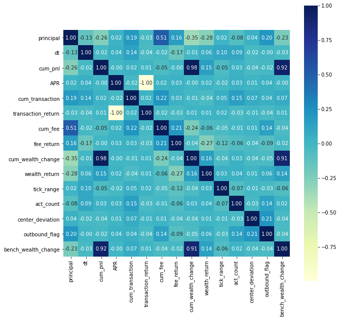

```python
plt.figure(figsize=(10,10))
sns.heatmap(cleared[key_variable].corr(),annot=True,fmt='.2f',cmap="YlGnBu",square=True)
```

Distribution by variable

```
<__array_function__ internals>:5: RuntimeWarning: Converting input from bool to <class 'numpy.uint8'> for compatibility.
```

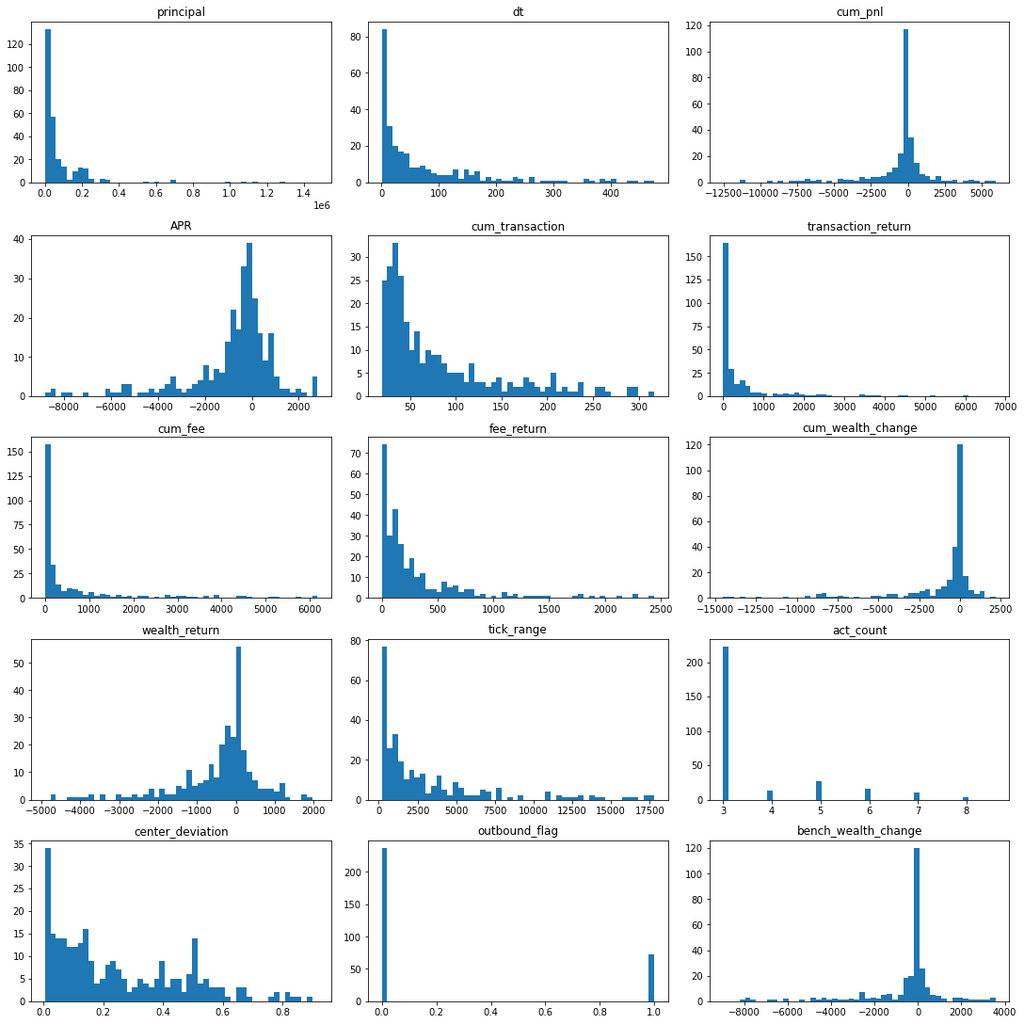

```python
fig,axes = plt.subplots(5,3,figsize=(15,15),constrained_layout=True)
for idx,v in enumerate(key_variable):
    axes[int(idx/3)][idx%3].hist(cleared[v],bins=50,range=(cleared[v].quantile(0.05),cleared[v].quantile(0.95)))
    axes[int(idx/3)][idx%3].set_title(v)
plt.show()
```

## Price change induced by swap

```python
transaction.loc[swap,'p_current'].diff().describe().to_frame('Price movement').T
```

|  | count | mean | std | min | 25% | 50% | 75% | max |
| --- | --- | --- | --- | --- | --- | --- | --- | --- |
| Price movement | 6064.0 | 0.727593 | 53.47071 | -767.45679 | -13.46248 | 0.076962 | 15.747496 | 783.935656 |

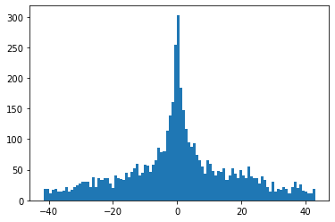

```python
plt.hist(transaction.loc[swap,'p_current'].diff(),bins=100,range=(transaction.loc[swap,'p_current'].diff().quantile(0.1),transaction.loc[swap,'p_current'].diff().quantile(0.9)))
plt.show()
```

```python
import statsmodels.api as sm
import scipy.stats as stats
```

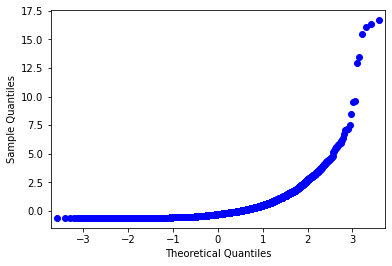

```python
temp = transaction.loc[swap,'p_current'].diff().dropna()
temp = temp[(temp>temp.quantile(0.2))&(temp<temp.quantile(0.8))]
sm.qqplot(transaction.loc[swap,'p_current'].diff().dropna().abs(),stats.norm,fit=True)
plt.show()
```

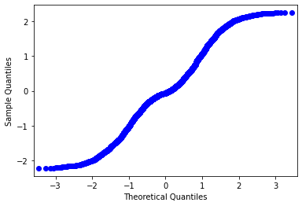

```python
sm.qqplot(temp,stats.norm,fit=True)
plt.show()
```

```python
# sm.qqplot(temp,stats.exponnorm,fit=True)
# plt.show()
```

# 1 基于position + LP 的分析

某个Liquidity provider在不同的position的action视为不同数据，不同liquidity provider在同一position的action视为不同数据

## 1.1 act_count

```python
cleared.groupby(['act_count'])[['cum_pnl','APR']].describe().T
```

|  | act_count | 3 | 4 | 5 | 6 | 7 | 8 | 9 | 10 | 13 | 14 | 15 | 16 | 18 | 24 |
| --- | --- | --- | --- | --- | --- | --- | --- | --- | --- | --- | --- | --- | --- | --- | --- |
| cum_pnl | count | 2.230000e+02 | 13.000000 | 27.000000 | 16.000000 | 11.000000 | 3.000000 | 4.000000 | 2.000000 | 2.000000 | 1.000000 | 3.000000 | 2.000000 | 1.000000 | 1.000000 |
|  | mean | -5.463956e+03 | -274.735650 | 52.481518 | -1421.254448 | 1095.923615 | -21576.733831 | 15.949334 | 927.334670 | -3111.034531 | -6719.000577 | -632.075629 | 4018.103827 | 1799.381646 | -402.277766 |
|  | std | 5.327242e+04 | 2474.828127 | 9395.680938 | 3793.800981 | 4635.294590 | 35311.282603 | 503.129254 | 1868.935784 | 999.995844 | NaN | 1241.224998 | 6110.943222 | NaN | NaN |
|  | min | -5.643329e+05 | -4351.345041 | -18691.734756 | -13463.102712 | -3799.492372 | -62350.176930 | -293.897772 | -394.202496 | -3818.138374 | -6719.000577 | -2052.912314 | -302.985565 | 1799.381646 | -402.277766 |
|  | 25% | -3.719840e+02 | -739.057642 | -1143.751013 | -1234.451713 | -604.309506 | -31858.740622 | -250.969469 | 266.566087 | -3464.586453 | -6719.000577 | -1068.766134 | 1857.559131 | 1799.381646 | -402.277766 |
|  | 50% | -6.692141e+01 | -103.184218 | -160.650751 | -231.979903 | -95.665998 | -1367.304314 | -204.640618 | 927.334670 | -3111.034531 | -6719.000577 | -84.619954 | 4018.103827 | 1799.381646 | -402.277766 |
|  | 75% | 1.062996e+02 | 373.975264 | 352.024035 | 559.795884 | 1056.170401 | -1190.012282 | 62.278184 | 1588.103253 | -2757.482610 | -6719.000577 | 78.342713 | 6178.648523 | 1799.381646 | -402.277766 |
|  | max | 3.248841e+05 | 6249.288928 | 30548.526954 | 1513.656871 | 14426.230433 | -1012.720249 | 766.976344 | 2248.871837 | -2403.930689 | -6719.000577 | 241.305381 | 8339.193218 | 1799.381646 | -402.277766 |
| APR | count | 2.230000e+02 | 13.000000 | 27.000000 | 16.000000 | 11.000000 | 3.000000 | 4.000000 | 2.000000 | 2.000000 | 1.000000 | 3.000000 | 2.000000 | 1.000000 | 1.000000 |
|  | mean | -2.382451e+04 | -726.300262 | -911.417913 | -669.413241 | 370.778856 | -1258.176731 | 11.079188 | 46.279560 | -707.778435 | -268.916236 | 32.768499 | 431.713220 | 333.897635 | -32.439518 |
|  | std | 2.519505e+05 | 1681.801251 | 2590.490472 | 2241.456526 | 1025.885016 | 766.948775 | 227.326307 | 285.038123 | 670.097347 | NaN | 240.518298 | 675.534909 | NaN | NaN |
|  | min | -3.676383e+06 | -6041.985946 | -8422.126808 | -6026.850890 | -263.445674 | -2115.912927 | -145.678917 | -155.272830 | -1181.608813 | -268.916236 | -154.985165 | -45.962095 | 333.897635 | -32.439518 |
|  | 25% | -1.895222e+03 | -721.991069 | -1103.643136 | -625.349149 | -145.111463 | -1568.039924 | -117.134574 | -54.496635 | -944.693624 | -268.916236 | -102.784917 | 192.875563 | 333.897635 | -32.439518 |
|  | 50% | -4.540873e+02 | -178.320556 | -249.657959 | -116.151219 | -26.914153 | -1020.166922 | -78.420483 | 46.279560 | -707.778435 | -268.916236 | -50.584668 | 431.713220 | 333.897635 | -32.439518 |
|  | 75% | 2.086447e+02 | 44.867913 | 524.962156 | 99.631845 | 338.442095 | -829.308633 | 49.793280 | 147.055754 | -470.863246 | -268.916236 | 126.645331 | 670.550877 | 333.897635 | -32.439518 |
|  | max | 2.300775e+04 | 443.001690 | 2865.455076 | 2848.994981 | 3257.867166 | -638.450343 | 346.836636 | 247.831949 | -233.948057 | -268.916236 | 303.875330 | 909.388535 | 333.897635 | -32.439518 |

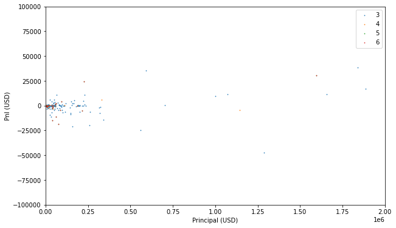

```python
plt.figure(figsize=(10,6))
plt.scatter(x='principal',y='cum_pnl',data=cleared[cleared['act_count']==3],s=0.5,label='3')
plt.scatter(x='principal',y='cum_pnl',data=cleared[cleared['act_count']==4],s=0.5,label='4')
plt.scatter(x='principal',y='cum_pnl',data=cleared[cleared['act_count']==5],s=0.5,label='5')
plt.scatter(x='principal',y='cum_pnl',data=cleared[cleared['act_count']==5],s=0.5,label='6')
plt.legend()
plt.xlim(0,2*10**(6))
plt.ylim(-10**5,10**(5))
plt.xlabel('Principal (USD)')
plt.ylabel('Pnl (USD)')
```

action数量 vs transaction cost

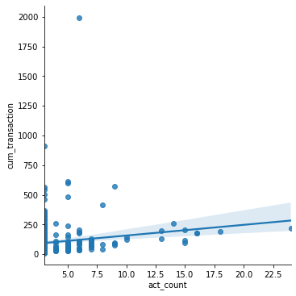

```python
sns.lmplot(data = cleared,x = 'act_count',y = 'cum_transaction')
```

```python
y = cleared['cum_transaction']
x = cleared['act_count']
x = sm.add_constant(x)
model = sm.OLS(y, x).fit() # 构建最小二乘模型并拟合
print(model.summary()) # 输出回归结果
```

```
                            OLS Regression Results
==============================================================================
Dep. Variable:        cum_transaction   R-squared:                       0.023
Model:                            OLS   Adj. R-squared:                  0.019
Method:                 Least Squares   F-statistic:                     7.113
Date:                Wed, 11 Aug 2021   Prob (F-statistic):            0.00806
Time:                        00:18:29   Log-Likelihood:                -1998.5
No. Observations:                 309   AIC:                             4001.
Df Residuals:                     307   BIC:                             4009.
Df Model:                           1
Covariance Type:            nonrobust
==============================================================================
                 coef    std err          t      P>|t|      [0.025      0.975]
------------------------------------------------------------------------------
const         67.4786     16.480      4.095      0.000      35.051      99.906
act_count      9.0166      3.381      2.667      0.008       2.364      15.669
==============================================================================
Omnibus:                      436.968   Durbin-Watson:                   2.087
Prob(Omnibus):                  0.000   Jarque-Bera (JB):            63800.848
Skew:                           6.803   Prob(JB):                         0.00
Kurtosis:                      72.067   Cond. No.                         9.30
==============================================================================

Notes:
[1] Standard Errors assume that the covariance matrix of the errors is correctly specified.
```

## 1.1 时间间隔对收益的影响

按时间间隔的quantile分成high(>75%)，midium high(50%-75%)，midium low(25%-50%)，low(<25%)

```python
cleared['dt_range'] = pd.qcut(cleared['dt'],4,labels=["L", "ML", "MH","H"])
```

时间间隔 vs 赚取的手续费

```python
cleared.groupby(['dt_range'])['cum_fee'].describe()
```

| dt_range | count | mean | std | min | 25% | 50% | 75% | max |
| --- | --- | --- | --- | --- | --- | --- | --- | --- |
| L | 78.0 | 2034.816940 | 13196.084222 | 0.0 | 0.000000 | 10.696323 | 258.185020 | 116093.697552 |
| ML | 77.0 | 1699.754269 | 6339.598515 | 0.0 | 11.088986 | 78.759018 | 240.394730 | 39532.872510 |
| MH | 77.0 | 2340.314424 | 9181.545999 | 0.0 | 80.150370 | 394.998451 | 1242.097744 | 78374.992203 |
| H | 77.0 | 1471.166253 | 2596.966939 | 0.0 | 39.440335 | 135.549040 | 1454.036323 | 11432.732588 |

```python
cleared.groupby(['dt_range'])['fee_return'].describe()
```

| dt_range | count | mean | std | min | 25% | 50% | 75% | max |
| --- | --- | --- | --- | --- | --- | --- | --- | --- |
| L | 78.0 | 1407.767517 | 2402.522122 | 0.0 | 0.000000 | 205.964487 | 1973.737161 | 14319.993652 |
| ML | 77.0 | 390.087799 | 507.096343 | 0.0 | 73.299747 | 265.091262 | 588.760796 | 3743.101497 |
| MH | 77.0 | 249.579677 | 220.601635 | 0.0 | 111.072841 | 177.504372 | 328.662119 | 1181.139652 |
| H | 77.0 | 139.683739 | 126.553963 | 0.0 | 58.195259 | 107.146230 | 179.557519 | 741.846489 |

时间间隔 vs wealth change

```python
cleared.groupby(['dt_range'])['cum_wealth_change'].describe()
```

| dt_range | count | mean | std | min | 25% | 50% | 75% | max |
| --- | --- | --- | --- | --- | --- | --- | --- | --- |
| L | 78.0 | -3020.813711 | 17425.862552 | -99490.555642 | -49.959542 | -0.000001 | 111.050196 | 17645.724288 |
| ML | 77.0 | -4065.604638 | 55431.125539 | -361347.005313 | -1153.338633 | -17.217355 | 68.685053 | 295403.227207 |
| MH | 77.0 | -6835.795232 | 33480.186441 | -261206.367619 | -2647.226058 | -298.766128 | 13.292810 | 32033.942382 |
| H | 77.0 | -10068.611236 | 65887.968503 | -574678.323157 | -2201.042955 | -257.883442 | -6.880855 | 18548.147750 |

```python
cleared.groupby(['dt_range'])['wealth_return'].describe()
```

| dt_range | count | mean | std | min | 25% | 50% | 75% | max |
| --- | --- | --- | --- | --- | --- | --- | --- | --- |
| L | 78.0 | -2866.023996 | 14795.667244 | -105839.704467 | -1012.464987 | -0.000030 | 944.767184 | 17814.494342 |
| ML | 77.0 | -767.711782 | 2362.023260 | -7710.000317 | -1877.530768 | -170.668519 | 318.100422 | 5687.717136 |
| MH | 77.0 | -461.753842 | 732.352740 | -2946.034812 | -1076.714946 | -269.415881 | 47.625445 | 986.675942 |
| H | 77.0 | -304.332459 | 513.362725 | -2462.462978 | -435.834047 | -220.472696 | -20.811318 | 637.335116 |

时间间隔 vs transaction cost

```python
cleared.groupby(['dt_range'])['cum_transaction'].describe()
```

| dt_range | count | mean | std | min | 25% | 50% | 75% | max |
| --- | --- | --- | --- | --- | --- | --- | --- | --- |
| L | 78.0 | 95.963983 | 111.614157 | 9.700198 | 29.758610 | 42.984264 | 118.236854 | 568.832088 |
| ML | 77.0 | 94.603258 | 231.417969 | 14.316567 | 30.640347 | 39.880875 | 82.467559 | 1995.372734 |
| MH | 77.0 | 93.542679 | 106.049416 | 15.597177 | 33.117831 | 58.161683 | 95.487849 | 574.659452 |
| H | 77.0 | 133.915364 | 149.800341 | 17.373236 | 45.624388 | 90.433666 | 157.203767 | 915.225642 |

```python
cleared.groupby(['dt_range'])['transaction_return'].describe()
```

| dt_range | count | mean | std | min | 25% | 50% | 75% | max |
| --- | --- | --- | --- | --- | --- | --- | --- | --- |
| L | 78.0 | 63417.214897 | 424404.877500 | 16.931098 | 188.607681 | 517.912327 | 2417.481635 | 3.676383e+06 |
| ML | 77.0 | 2580.343528 | 15748.458538 | 0.353967 | 28.347601 | 106.840485 | 453.309607 | 1.355453e+05 |
| MH | 77.0 | 245.425613 | 863.940067 | 0.212613 | 8.525745 | 29.366458 | 85.863006 | 5.959292e+03 |
| H | 77.0 | 281.079899 | 723.965768 | 0.040037 | 12.628466 | 35.421815 | 123.796727 | 4.376243e+03 |

```python
cleared.groupby(['dt_range'])['act_count'].describe()
```

| dt_range | count | mean | std | min | 25% | 50% | 75% | max |
| --- | --- | --- | --- | --- | --- | --- | --- | --- |
| L | 78.0 | 3.294872 | 0.869527 | 3.0 | 3.0 | 3.0 | 3.0 | 7.0 |
| ML | 77.0 | 3.597403 | 1.741594 | 3.0 | 3.0 | 3.0 | 3.0 | 16.0 |
| MH | 77.0 | 4.623377 | 2.879323 | 3.0 | 3.0 | 3.0 | 5.0 | 16.0 |
| H | 77.0 | 4.909091 | 3.766828 | 3.0 | 3.0 | 3.0 | 5.0 | 24.0 |

时间间隔 vs pnl/APR

```python
cleared.groupby(['dt_range'])['cum_pnl'].describe()
```

| dt_range | count | mean | std | min | 25% | 50% | 75% | max |
| --- | --- | --- | --- | --- | --- | --- | --- | --- |
| L | 78.0 | -1081.960754 | 12379.701965 | -81359.925615 | -175.726577 | -30.454784 | 168.094769 | 17076.892200 |
| ML | 77.0 | -2460.453626 | 57735.672403 | -361534.533233 | -928.153170 | -66.921408 | 114.758108 | 324884.115971 |
| MH | 77.0 | -4589.023487 | 26063.153055 | -183375.030064 | -1796.006434 | -176.402173 | 376.635380 | 35615.455544 |
| H | 77.0 | -8731.360347 | 64762.035468 | -564332.894559 | -958.252697 | -172.621202 | 173.024812 | 24119.437180 |

```python
cleared.groupby(['dt_range'])['APR'].describe()
```

| dt_range | count | mean | std | min | 25% | 50% | 75% | max |
| --- | --- | --- | --- | --- | --- | --- | --- | --- |
| L | 78.0 | -64875.471376 | 424429.335840 | -3.676383e+06 | -5896.660207 | -600.828025 | 1337.527666 | 23007.746554 |
| ML | 77.0 | -2957.967511 | 15941.753676 | -1.364918e+05 | -2210.641055 | -362.551707 | 591.495770 | 5699.761806 |
| MH | 77.0 | -457.599779 | 1146.635591 | -5.655534e+03 | -937.060547 | -198.522172 | 198.891426 | 1096.989959 |
| H | 77.0 | -445.728619 | 875.873354 | -4.584025e+03 | -688.614781 | -254.382806 | 26.279517 | 1115.030490 |

## 1.2 价格区间对收益的影响

### log 价格区间

tick_range = tickUpper - tickLower 1 tick 约相当于价格0.01%

```python
cleared['tick_range'] =  cleared.index.map(lambda x:x[1]-x[2])
cleared['tick_range'].describe().to_frame().T
```

|  | count | mean | std | min | 25% | 50% | 75% | max |
| --- | --- | --- | --- | --- | --- | --- | --- | --- |
| tick_range | 309.0 | 4889.967638 | 13557.259389 | 200.0 | 600.0 | 1600.0 | 4600.0 | 196600.0 |

### USD/ETH 价格区间

price_range = 1/(1.0001^tickLower/10^12) - 1/(1.0001^tickUpper/10^12)

```python
cleared['price_range'] =  cleared.index.map(lambda x:1/(1.0001**x[2]/10**12)-1/(1.0001**x[1]/10**12))
cleared['price_range'].describe().to_frame().T
```

|  | count | mean | std | min | 25% | 50% | 75% | max |
| --- | --- | --- | --- | --- | --- | --- | --- | --- |
| price_range | 309.0 | 140457.662154 | 2.433429e+06 | 0.00011 | 120.146498 | 402.082844 | 1035.175706 | 4.277755e+07 |

```python
cleared['tick_range_range'] = pd.qcut(cleared['tick_range'],4,labels=["L", "ML", "MH","H"])
```

价格区间 vs 时间间隔

```python
cleared.groupby(['tick_range_range'])['dt'].describe()
```

| tick_range_range | count | mean | std | min | 25% | 50% | 75% | max |
| --- | --- | --- | --- | --- | --- | --- | --- | --- |
| L | 94.0 | 53.603534 | 131.128294 | 0.125556 | 2.432847 | 11.121389 | 45.834792 | 1070.841111 |
| ML | 61.0 | 71.216926 | 106.957294 | 0.232778 | 8.110278 | 29.368611 | 75.481667 | 487.744167 |
| MH | 78.0 | 120.556321 | 161.433228 | 0.198333 | 11.935903 | 63.216250 | 149.810347 | 755.282778 |
| H | 76.0 | 173.350939 | 258.006131 | 0.058333 | 10.524653 | 47.399028 | 193.698819 | 1080.101389 |

价格区间 vs 赚取的手续费

```python
cleared.groupby(['tick_range_range'])['cum_fee'].describe()
```

| tick_range_range | count | mean | std | min | 25% | 50% | 75% | max |
| --- | --- | --- | --- | --- | --- | --- | --- | --- |
| L | 94.0 | 2408.422555 | 12275.918367 | 0.0 | 13.344439 | 180.585753 | 671.988914 | 116093.697552 |
| ML | 61.0 | 2752.317316 | 11154.366516 | 0.0 | 27.902792 | 155.554362 | 1019.116915 | 78374.992203 |
| MH | 78.0 | 1819.192473 | 4494.423751 | 0.0 | 38.521855 | 172.203010 | 1070.946880 | 29983.926356 |
| H | 76.0 | 617.114774 | 1576.083303 | 0.0 | 0.526769 | 33.911499 | 185.338537 | 10368.151434 |

```python
cleared.groupby(['tick_range_range'])['fee_return'].describe()
```

| tick_range_range | count | mean | std | min | 25% | 50% | 75% | max |
| --- | --- | --- | --- | --- | --- | --- | --- | --- |
| L | 94.0 | 1221.242024 | 2159.129645 | 0.0 | 108.154099 | 445.354654 | 1395.225859 | 14319.993652 |
| ML | 61.0 | 458.799851 | 651.920444 | 0.0 | 140.592969 | 290.165300 | 544.542760 | 3935.022859 |
| MH | 78.0 | 268.132194 | 540.433504 | 0.0 | 97.363734 | 157.227929 | 264.706010 | 4662.927311 |
| H | 76.0 | 80.500756 | 105.366608 | 0.0 | 3.734846 | 59.477938 | 114.767851 | 647.135558 |

价格区间 vs wealth change

```python
cleared.groupby(['tick_range_range'])['cum_wealth_change'].describe()
```

| tick_range_range | count | mean | std | min | 25% | 50% | 75% | max |
| --- | --- | --- | --- | --- | --- | --- | --- | --- |
| L | 94.0 | -6988.212527 | 40315.359564 | -361347.005313 | -809.313791 | -20.890523 | 2.481861e+01 | 17645.724288 |
| ML | 61.0 | -4945.060725 | 33476.883856 | -261206.367619 | -845.507407 | -76.646537 | 2.323062e+01 | 10298.351432 |
| MH | 78.0 | 371.116474 | 35826.379768 | -68868.978789 | -2070.527921 | -139.079370 | 8.282769e+01 | 295403.227207 |
| H | 76.0 | -12114.746419 | 68404.229354 | -574678.323157 | -2662.277561 | -10.443260 | -9.999785e-07 | 32033.942382 |

```python
cleared['APR'].quantile(0.7)
```

```
43.1871295939561
```

```python
cleared.groupby(['tick_range_range'])['wealth_return'].describe()
```

| tick_range_range | count | mean | std | min | 25% | 50% | 75% | max |
| --- | --- | --- | --- | --- | --- | --- | --- | --- |
| L | 94.0 | -1747.593233 | 6888.009239 | -54598.253407 | -1730.715199 | -120.247888 | 1.620938e+02 | 10207.836735 |
| ML | 61.0 | -770.231600 | 5364.571360 | -36539.906013 | -1196.271465 | -178.406806 | 9.947707e+01 | 17814.494342 |
| MH | 78.0 | -1547.999517 | 12057.568048 | -105839.704467 | -708.377337 | -173.688630 | 1.482000e+02 | 5687.717136 |
| H | 76.0 | -126.979871 | 1655.381450 | -4699.512006 | -419.905734 | -94.268699 | -8.867419e-08 | 8706.767157 |

价格区间 vs transaction cost

```python
cleared.groupby(['tick_range_range'])['cum_transaction'].describe()
```

| tick_range_range | count | mean | std | min | 25% | 50% | 75% | max |
| --- | --- | --- | --- | --- | --- | --- | --- | --- |
| L | 94.0 | 110.211343 | 112.925916 | 12.897660 | 34.968428 | 76.798717 | 155.857805 | 574.659452 |
| ML | 61.0 | 80.150495 | 89.568196 | 13.461149 | 32.536334 | 43.979824 | 93.675059 | 543.654648 |
| MH | 78.0 | 93.187775 | 113.028792 | 9.700198 | 30.119043 | 54.905209 | 92.473181 | 614.215363 |
| H | 76.0 | 128.502869 | 256.505356 | 15.330651 | 31.713576 | 55.169431 | 116.879045 | 1995.372734 |

```python
cleared.groupby(['tick_range_range'])['transaction_return'].describe()
```

| tick_range_range | count | mean | std | min | 25% | 50% | 75% | max |
| --- | --- | --- | --- | --- | --- | --- | --- | --- |
| L | 94.0 | 4326.574244 | 24809.770262 | 0.944249 | 48.235178 | 168.247260 | 898.311350 | 2.009407e+05 |
| ML | 61.0 | 1819.316189 | 7872.315277 | 0.940657 | 20.535980 | 122.951054 | 453.309607 | 5.537544e+04 |
| MH | 78.0 | 995.164909 | 6271.555485 | 0.333107 | 12.964496 | 41.297186 | 183.084856 | 5.494081e+04 |
| H | 76.0 | 60400.934326 | 429869.254486 | 0.040037 | 12.657625 | 63.945036 | 641.387608 | 3.676383e+06 |

```python
cleared.groupby(['tick_range_range'])['act_count'].describe()
```

| tick_range_range | count | mean | std | min | 25% | 50% | 75% | max |
| --- | --- | --- | --- | --- | --- | --- | --- | --- |
| L | 94.0 | 4.691489 | 3.340937 | 3.0 | 3.0 | 3.0 | 5.75 | 24.0 |
| ML | 61.0 | 3.868852 | 2.261824 | 3.0 | 3.0 | 3.0 | 3.00 | 15.0 |
| MH | 78.0 | 3.974359 | 2.558278 | 3.0 | 3.0 | 3.0 | 4.00 | 18.0 |
| H | 76.0 | 3.697368 | 1.789001 | 3.0 | 3.0 | 3.0 | 3.00 | 15.0 |

价格区间 vs pnl/APR

```python
cleared.groupby(['tick_range_range'])['cum_pnl'].describe()
```

| tick_range_range | count | mean | std | min | 25% | 50% | 75% | max |
| --- | --- | --- | --- | --- | --- | --- | --- | --- |
| L | 94.0 | -4690.001314 | 39022.969504 | -361534.533233 | -450.263160 | -78.848590 | 224.691938 | 38551.214749 |
| ML | 61.0 | -2272.893904 | 24104.143671 | -183375.030064 | -346.871434 | -87.632599 | 168.344423 | 30548.526954 |
| MH | 78.0 | 2097.121172 | 38469.315764 | -66089.241234 | -1047.925862 | -88.176966 | 418.185900 | 324884.115971 |
| H | 76.0 | -11626.134514 | 67343.693008 | -564332.894559 | -2119.091383 | -94.834345 | -21.764888 | 35615.455544 |

```python
cleared.groupby(['tick_range_range'])['APR'].describe()
```

| tick_range_range | count | mean | std | min | 25% | 50% | 75% | max |
| --- | --- | --- | --- | --- | --- | --- | --- | --- |
| L | 94.0 | -4852.925453 | 25680.722082 | -2.009407e+05 | -2518.007795 | -269.596498 | 343.872933 | 23007.746554 |
| ML | 61.0 | -2130.747938 | 9689.187680 | -5.540116e+04 | -1379.188436 | -377.091975 | 303.875330 | 20028.761446 |
| MH | 78.0 | -2275.032232 | 13090.466713 | -1.015677e+05 | -751.596283 | -242.987311 | 307.523981 | 5699.761806 |
| H | 76.0 | -60447.413440 | 429860.682583 | -3.676383e+06 | -1352.689318 | -415.676406 | -24.714732 | 2660.397819 |

```python
cleared['outbound_flag'] = transaction.loc[mint].groupby(info)['outbound_flag'].sum().loc[cleared_position]>0
cleared['outbound_flag'].describe().to_frame().T
```

|  | count | unique | top | freq |
| --- | --- | --- | --- | --- |
| outbound_flag | 309 | 2 | False | 237 |

## outbound_flag

是否有mint时current price不在所设定的区间内的，是则为True

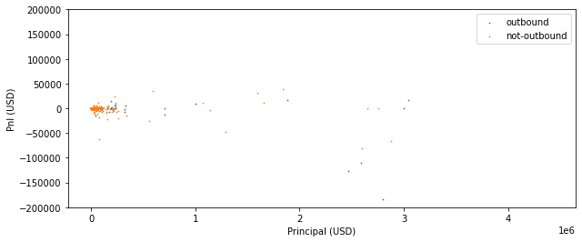

```python
plt.figure(figsize=(10,4))
plt.scatter(x='principal',y='cum_pnl',data=cleared[cleared['outbound_flag']==True],s=0.5,label='outbound')
plt.scatter(x='principal',y='cum_pnl',data=cleared[cleared['outbound_flag']==False],s=0.5,label='not-outbound')
plt.legend()
plt.ylim(-0.2*10**6,0.2*10**(6))
plt.xlabel('Principal (USD)')
plt.ylabel('Pnl (USD)')
```

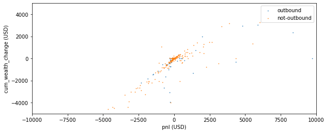

```python
plt.figure(figsize=(10,4))
plt.scatter(x='cum_pnl',y='cum_wealth_change',data=cleared[cleared['outbound_flag']==True],s=0.5,label='outbound')
plt.scatter(x='cum_pnl',y='cum_wealth_change',data=cleared[cleared['outbound_flag']==False],s=0.5,label='not-outbound')
plt.legend()
plt.ylim(-5000,5000)
plt.xlim(-10000,10000)
plt.xlabel('pnl (USD)')
plt.ylabel('cum_wealth_change (USD)')
```

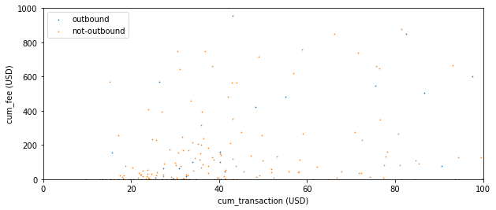

```python
plt.figure(figsize=(10,4))
plt.scatter(x='cum_transaction',y='cum_fee',data=cleared[cleared['outbound_flag']==True],s=0.5,label='outbound')
plt.scatter(x='cum_transaction',y='cum_fee',data=cleared[cleared['outbound_flag']==False],s=0.5,label='not-outbound')
plt.legend()
plt.ylim(0,1000)
plt.xlim(0,100)
plt.xlabel('cum_transaction (USD)')
plt.ylabel('cum_fee (USD)')
```

```python
cleared.groupby(['outbound_flag'])[['cum_pnl','APR']].describe().T
```

|  | outbound_flag | False | True |
| --- | --- | --- | --- |
| cum_pnl | count | 2.370000e+02 | 72.000000 |
|  | mean | -3.679922e+03 | -5935.776562 |
|  | std | 3.797659e+04 | 64726.697662 |
|  | min | -5.643329e+05 | -361534.533233 |
|  | 25% | -7.092100e+02 | -503.163247 |
|  | 50% | -8.448098e+01 | -148.211346 |
|  | 75% | 1.706858e+02 | 239.994669 |
|  | max | 3.855121e+04 | 324884.115971 |
| APR | count | 2.370000e+02 | 72.000000 |
|  | mean | -2.193880e+04 | -2195.988039 |
|  | std | 2.443079e+05 | 16300.638746 |
|  | min | -3.676383e+06 | -136491.757086 |
|  | 25% | -1.709706e+03 | -676.613388 |
|  | 50% | -4.418147e+02 | -139.882361 |
|  | 75% | 3.038753e+02 | 25.220126 |
|  | max | 2.300775e+04 | 15778.464793 |

```python
cleared.groupby(['outbound_flag'])[['cum_transaction','transaction_return']].describe().T
```

|  | outbound_flag | False | True |
| --- | --- | --- | --- |
| cum_transaction | count | 2.370000e+02 | 72.000000 |
|  | mean | 1.009058e+02 | 116.239416 |
|  | std | 1.643344e+02 | 134.912233 |
|  | min | 1.289766e+01 | 9.700198 |
|  | 25% | 3.213734e+01 | 32.508102 |
|  | 50% | 5.231501e+01 | 60.652057 |
|  | 75% | 1.099020e+02 | 150.972643 |
|  | max | 1.995373e+03 | 601.353076 |
| transaction_return | count | 2.370000e+02 | 72.000000 |
|  | mean | 2.117619e+04 | 2319.627762 |
|  | std | 2.442350e+05 | 15979.261420 |
|  | min | 4.003738e-02 | 0.191248 |
|  | 25% | 3.027911e+01 | 6.283958 |
|  | 50% | 1.237967e+02 | 26.264426 |
|  | 75% | 5.492276e+02 | 151.278598 |
|  | max | 3.676383e+06 | 135545.289464 |

```python
cleared.groupby(['outbound_flag'])[['cum_fee', 'fee_return']].describe().T
```

|  | outbound_flag | False | True |
| --- | --- | --- | --- |
| cum_fee | count | 237.000000 | 72.000000 |
|  | mean | 1210.852744 | 4112.620996 |
|  | std | 3706.352652 | 16661.089495 |
|  | min | 0.000000 | 0.000000 |
|  | 25% | 20.922588 | 0.000000 |
|  | 50% | 130.849271 | 75.935844 |
|  | 75% | 675.716137 | 1003.758414 |
|  | max | 39532.872510 | 116093.697552 |
| fee_return | count | 237.000000 | 72.000000 |
|  | mean | 612.715936 | 341.697679 |
|  | std | 1410.282001 | 1026.053840 |
|  | min | 0.000000 | 0.000000 |
|  | 25% | 86.519536 | 0.000000 |
|  | 50% | 188.720172 | 50.826860 |
|  | 75% | 550.502588 | 245.776030 |
|  | max | 14319.993652 | 6284.432933 |

```python
cleared.groupby(['outbound_flag'])[['cum_wealth_change', 'wealth_return']].describe().T
```

|  | outbound_flag | False | True |
| --- | --- | --- | --- |
| cum_wealth_change | count | 237.000000 | 7.200000e+01 |
|  | mean | -4789.868938 | -9.932158e+03 |
|  | std | 38753.257025 | 6.697105e+04 |
|  | min | -574678.323157 | -3.613470e+05 |
|  | 25% | -873.408408 | -1.522124e+03 |
|  | 50% | -25.689876 | -1.632534e+02 |
|  | 75% | 50.277929 | -9.999984e-07 |
|  | max | 32033.942382 | 2.954032e+05 |
| wealth_return | count | 237.000000 | 7.200000e+01 |
|  | mean | -1375.325532 | -2.180580e+02 |
|  | std | 8549.584433 | 2.215239e+03 |
|  | min | -105839.704467 | -7.710000e+03 |
|  | 25% | -1076.714946 | -4.795002e+02 |
|  | 50% | -147.704242 | -1.129873e+02 |
|  | 75% | 185.725229 | -8.867419e-08 |
|  | max | 17814.494342 | 9.680718e+03 |

```python
cleared.groupby(['outbound_flag'])[['act_count', 'tick_range']].describe().T
```

|  | outbound_flag | False | True |
| --- | --- | --- | --- |
| act_count | count | 237.000000 | 72.000000 |
|  | mean | 3.907173 | 4.750000 |
|  | std | 2.158897 | 3.751995 |
|  | min | 3.000000 | 3.000000 |
|  | 25% | 3.000000 | 3.000000 |
|  | 50% | 3.000000 | 3.000000 |
|  | 75% | 4.000000 | 5.250000 |
|  | max | 18.000000 | 24.000000 |
| tick_range | count | 237.000000 | 72.000000 |
|  | mean | 5101.265823 | 4194.444444 |
|  | std | 14993.598863 | 7031.195857 |
|  | min | 200.000000 | 200.000000 |
|  | 25% | 600.000000 | 200.000000 |
|  | 50% | 1800.000000 | 1000.000000 |
|  | 75% | 4600.000000 | 4350.000000 |
|  | max | 196600.000000 | 32200.000000 |

## Center deviation

position的中点偏离当前价格占position宽度的比例

```python
cleared['center_deviation_range'] = pd.qcut(cleared['center_deviation'],4,labels=["L", "ML", "MH","H"])
cleared['center_deviation'].describe().to_frame().T
```

|  | count | mean | std | min | 25% | 50% | 75% | max |
| --- | --- | --- | --- | --- | --- | --- | --- | --- |
| center_deviation | 309.0 | 0.428785 | 2.34822 | 0.00005 | 0.057569 | 0.169149 | 0.44225 | 40.940827 |

```python
cleared.groupby(['center_deviation_range'])[['cum_pnl','APR']].describe().T
```

|  | center_deviation_range | L | ML | MH | H |
| --- | --- | --- | --- | --- | --- |
| cum_pnl | count | 78.000000 | 7.700000e+01 | 77.000000 | 77.000000 |
|  | mean | -1397.695029 | -6.279085e+02 | -8946.049470 | -5887.044768 |
|  | std | 13643.459861 | 3.559444e+03 | 65051.810500 | 62581.131441 |
|  | min | -81359.925615 | -2.494035e+04 | -564332.894559 | -361534.533233 |
|  | 25% | -661.237110 | -5.186433e+02 | -1821.610848 | -573.327992 |
|  | 50% | -112.361633 | -3.491787e+01 | -95.212460 | -133.319887 |
|  | 75% | 79.012528 | 3.758780e+02 | 114.758108 | 318.109063 |
|  | max | 38551.214749 | 5.519409e+03 | 30548.526954 | 324884.115971 |
| APR | count | 78.000000 | 7.700000e+01 | 77.000000 | 77.000000 |
|  | mean | -3104.500666 | -4.844224e+04 | -15858.300318 | -2133.947547 |
|  | std | 9800.321719 | 4.189213e+05 | 92779.499097 | 15759.832911 |
|  | min | -55401.164763 | -3.676383e+06 | -786348.281758 | -136491.757086 |
|  | 25% | -1663.984828 | -1.270226e+03 | -2002.254278 | -708.008806 |
|  | 50% | -561.948171 | -2.496580e+02 | -570.573408 | -168.420724 |
|  | 75% | 306.502616 | 3.338976e+02 | 204.398248 | 37.291701 |
|  | max | 3478.198295 | 2.300775e+04 | 20028.761446 | 15778.464793 |

```python
cleared.groupby(['center_deviation_range'])[['cum_transaction','transaction_return']].describe().T
```

|  | center_deviation_range | L | ML | MH | H |
| --- | --- | --- | --- | --- | --- |
| cum_transaction | count | 78.000000 | 7.700000e+01 | 77.000000 | 77.000000 |
|  | mean | 128.465132 | 8.108998e+01 | 95.965870 | 112.082206 |
|  | std | 251.797430 | 8.202346e+01 | 98.400613 | 138.244036 |
|  | min | 15.330651 | 1.597676e+01 | 15.111805 | 9.700198 |
|  | 25% | 32.591606 | 3.281169e+01 | 33.604150 | 31.449248 |
|  | 50% | 58.127832 | 4.397982e+01 | 52.315006 | 57.016671 |
|  | 75% | 114.387173 | 1.032012e+02 | 123.248728 | 129.639828 |
|  | max | 1995.372734 | 5.746595e+02 | 614.215363 | 601.353076 |
| transaction_return | count | 78.000000 | 7.700000e+01 | 77.000000 | 77.000000 |
|  | mean | 2407.819798 | 4.839741e+04 | 14335.959054 | 2175.206548 |
|  | std | 8328.820444 | 4.188904e+05 | 92210.755999 | 15454.349096 |
|  | min | 0.758824 | 1.264434e+00 | 0.040037 | 0.191248 |
|  | 25% | 36.492873 | 3.542182e+01 | 17.623672 | 6.546418 |
|  | 50% | 152.262088 | 1.229511e+02 | 81.326059 | 29.131033 |
|  | 75% | 459.788121 | 6.157318e+02 | 681.964735 | 172.234758 |
|  | max | 55375.442743 | 3.676383e+06 | 786348.278229 | 135545.289464 |

```python
cleared.groupby(['center_deviation_range'])[['cum_fee', 'fee_return']].describe().T
```

|  | center_deviation_range | L | ML | MH | H |
| --- | --- | --- | --- | --- | --- |
| cum_fee | count | 78.000000 | 77.000000 | 77.000000 | 77.000000 |
|  | mean | 1593.253075 | 540.769132 | 1559.312396 | 3858.451877 |
|  | std | 4052.079344 | 984.307500 | 4929.791941 | 16131.533855 |
|  | min | 0.000000 | 0.000000 | 0.000000 | 0.000000 |
|  | 25% | 28.896043 | 30.490636 | 15.695473 | 0.000000 |
|  | 50% | 160.557867 | 129.503129 | 135.549040 | 64.960585 |
|  | 75% | 824.297996 | 566.560438 | 747.664752 | 955.597078 |
|  | max | 24047.938943 | 4356.244936 | 39532.872510 | 116093.697552 |
| fee_return | count | 78.000000 | 77.000000 | 77.000000 | 77.000000 |
|  | mean | 593.176323 | 779.900173 | 505.686616 | 318.934725 |
|  | std | 1071.105807 | 2021.617905 | 927.567119 | 995.846593 |
|  | min | 0.000000 | 0.000000 | 0.000000 | 0.000000 |
|  | 25% | 118.474567 | 86.169391 | 64.266647 | 0.000000 |
|  | 50% | 223.239601 | 174.467866 | 177.480598 | 43.458462 |
|  | 75% | 573.082323 | 474.679499 | 550.502588 | 187.797716 |
|  | max | 7699.982678 | 14319.993652 | 4934.767397 | 6284.432933 |

```python
cleared.groupby(['center_deviation_range'])[['cum_wealth_change', 'wealth_return']].describe().T
```

|  | center_deviation_range | L | ML | MH | H |
| --- | --- | --- | --- | --- | --- |
| cum_wealth_change | count | 78.000000 | 77.000000 | 77.000000 | 7.700000e+01 |
|  | mean | -2862.482973 | -1087.587651 | -10409.395996 | -9.633414e+03 |
|  | std | 14895.533667 | 3817.867764 | 66099.743836 | 6.478131e+04 |
|  | min | -94471.238060 | -26696.760246 | -574678.323157 | -3.613470e+05 |
|  | 25% | -750.550993 | -658.378946 | -2664.602057 | -1.652060e+03 |
|  | 50% | -49.730397 | -16.091169 | -25.689876 | -1.540663e+02 |
|  | 75% | 64.083272 | 166.765635 | 24.848749 | -1.000000e-06 |
|  | max | 32033.942382 | 2897.010816 | 18548.147750 | 2.954032e+05 |
| wealth_return | count | 78.000000 | 77.000000 | 77.000000 | 7.700000e+01 |
|  | mean | -1289.857192 | -824.730981 | -2028.027881 | -2.776757e+02 |
|  | std | 6418.122731 | 4867.561749 | 12677.328556 | 2.173609e+03 |
|  | min | -54598.253407 | -36539.906013 | -105839.704467 | -7.710000e+03 |
|  | 25% | -1166.292302 | -741.389713 | -1012.576675 | -5.063493e+02 |
|  | 50% | -152.776464 | -34.300147 | -170.668519 | -1.460609e+02 |
|  | 75% | 301.829782 | 239.440240 | 133.672172 | -2.279241e-07 |
|  | max | 2531.128223 | 10207.836735 | 17814.494342 | 9.680718e+03 |

```python
cleared.groupby(['center_deviation_range'])[['act_count', 'tick_range']].describe().T
```

|  | center_deviation_range | L | ML | MH | H |
| --- | --- | --- | --- | --- | --- |
| act_count | count | 78.000000 | 77.000000 | 77.000000 | 77.000000 |
|  | mean | 3.769231 | 4.376623 | 4.194805 | 4.077922 |
|  | std | 2.113181 | 2.795857 | 2.680529 | 2.900845 |
|  | min | 3.000000 | 3.000000 | 3.000000 | 3.000000 |
|  | 25% | 3.000000 | 3.000000 | 3.000000 | 3.000000 |
|  | 50% | 3.000000 | 3.000000 | 3.000000 | 3.000000 |
|  | 75% | 3.000000 | 5.000000 | 4.000000 | 3.000000 |
|  | max | 15.000000 | 18.000000 | 16.000000 | 24.000000 |
| tick_range | count | 78.000000 | 77.000000 | 77.000000 | 77.000000 |
|  | mean | 6151.282051 | 3329.870130 | 5038.961039 | 5023.376623 |
|  | std | 22489.205166 | 4954.399027 | 11151.872109 | 8910.784361 |
|  | min | 200.000000 | 200.000000 | 200.000000 | 200.000000 |
|  | 25% | 650.000000 | 400.000000 | 400.000000 | 200.000000 |
|  | 50% | 2000.000000 | 1600.000000 | 2200.000000 | 1200.000000 |
|  | 75% | 4400.000000 | 3800.000000 | 5000.000000 | 5200.000000 |
|  | max | 196600.000000 | 27000.000000 | 92200.000000 | 55200.000000 |

## 1.3 年化收益率高的position特点分析

- fee earned年化更高
- wealth change基本为正值
- 持有时间短（基本短于2天）
- 支付的transaction cost绝对值区别不大
- 价格区间相对较窄

```python
cleared['APR_range'] = pd.qcut(cleared['APR'],4,labels=["L", "ML", "MH","H"])
cleared.groupby(['APR_range'])['fee_return'].describe()
```

| APR_range | count | mean | std | min | 25% | 50% | 75% | max |
| --- | --- | --- | --- | --- | --- | --- | --- | --- |
| L | 78.0 | 701.557692 | 1352.869931 | 0.0 | 1.585745 | 162.902530 | 648.658681 | 7699.982678 |
| ML | 77.0 | 201.940388 | 262.153242 | 0.0 | 28.869946 | 130.687809 | 250.815813 | 1497.437043 |
| MH | 77.0 | 158.730116 | 298.979106 | 0.0 | 24.509939 | 101.665989 | 187.015408 | 2441.453995 |
| H | 77.0 | 1134.062090 | 2133.881426 | 0.0 | 201.669468 | 474.679499 | 1092.495306 | 14319.993652 |

```python
cleared.groupby(['APR_range'])[['wealth_return']].describe()
```

| APR_range | wealth_return count | wealth_return mean | wealth_return std | wealth_return min | wealth_return 25% | wealth_return 50% | wealth_return 75% | wealth_return max |
| --- | --- | --- | --- | --- | --- | --- | --- | --- |
| L | 78.0 | -5070.174560 | 14050.218861 | -105839.704467 | -3984.933881 | -1935.716566 | -9.777298e+01 | 2531.128223 |
| ML | 77.0 | -503.266043 | 1177.073792 | -1575.513942 | -996.013355 | -636.565029 | -2.380582e+02 | 8706.767157 |
| MH | 77.0 | -147.390013 | 333.263598 | -2535.910937 | -254.707688 | -70.282154 | -4.783583e-08 | 271.205372 |
| H | 77.0 | 1349.633869 | 2738.341365 | -4660.392327 | 248.192830 | 534.503136 | 1.213800e+03 | 17814.494342 |

```python
cleared.groupby(['APR_range'])[['cum_wealth_change']].describe()
```

| APR_range | cum_wealth_change count | cum_wealth_change mean | cum_wealth_change std | cum_wealth_change min | cum_wealth_change 25% | cum_wealth_change 50% | cum_wealth_change 75% | cum_wealth_change max |
| --- | --- | --- | --- | --- | --- | --- | --- | --- |
| L | 78.0 | -14197.771664 | 52928.977194 | -361347.005313 | -2227.722405 | -238.774198 | -2.518575e-01 | 40.007311 |
| ML | 77.0 | -12413.633285 | 67046.850565 | -574678.323157 | -2664.602057 | -311.589975 | -3.514639e+01 | 1078.757593 |
| MH | 77.0 | -1664.268790 | 3204.247145 | -15369.594237 | -1652.060086 | -199.733388 | -9.999931e-07 | 687.069636 |
| H | 77.0 | 4430.004221 | 35902.602174 | -99490.555642 | 85.627063 | 275.097895 | 1.440883e+03 | 295403.227207 |

```python
cleared['pnl_range'] = pd.qcut(cleared['cum_pnl'],4,labels=["L", "ML", "MH","H"])
cleared.groupby(['pnl_range'])['cum_wealth_change'].describe()
```

| pnl_range | count | mean | std | min | 25% | 50% | 75% | max |
| --- | --- | --- | --- | --- | --- | --- | --- | --- |
| L | 78.0 | -27518.089562 | 82710.162430 | -574678.323157 | -10228.048030 | -4413.060775 | -2076.998352 | 1078.757593 |
| ML | 77.0 | -469.212600 | 935.564098 | -5469.464487 | -471.318203 | -199.733388 | -16.738924 | 94.986840 |
| MH | 77.0 | 7.210507 | 63.927796 | -234.626918 | -10.303669 | -0.000001 | 16.633491 | 233.462936 |
| H | 77.0 | 4307.413278 | 35923.837784 | -99490.555642 | 14.282195 | 315.963550 | 1440.883057 | 295403.227207 |

```python
cleared.groupby(['APR_range'])[['cum_transaction']].describe()
```

| APR_range | cum_transaction count | cum_transaction mean | cum_transaction std | cum_transaction min | cum_transaction 25% | cum_transaction 50% | cum_transaction 75% | cum_transaction max |
| --- | --- | --- | --- | --- | --- | --- | --- | --- |
| L | 78.0 | 104.673156 | 103.986233 | 14.316567 | 33.698956 | 65.743565 | 148.928615 | 543.654648 |
| ML | 77.0 | 122.261285 | 258.699074 | 12.897660 | 30.995418 | 40.261206 | 109.901992 | 1995.372734 |
| MH | 77.0 | 82.600992 | 66.419801 | 9.700198 | 31.876622 | 58.231807 | 107.675320 | 291.969150 |
| H | 77.0 | 108.376745 | 133.872616 | 18.765591 | 38.485149 | 55.645922 | 103.201231 | 614.215363 |

```python
cleared.groupby(['APR_range'])[['dt']].describe()
```

| APR_range | dt count | dt mean | dt std | dt min | dt 25% | dt 50% | dt 75% | dt max |
| --- | --- | --- | --- | --- | --- | --- | --- | --- |
| L | 78.0 | 52.038714 | 147.301387 | 0.058333 | 1.422083 | 7.795139 | 25.018750 | 1080.101389 |
| ML | 77.0 | 141.139325 | 207.585763 | 0.125556 | 15.451111 | 57.868889 | 170.101944 | 1070.841111 |
| MH | 77.0 | 173.239574 | 222.918791 | 0.168333 | 24.496944 | 82.022222 | 200.365000 | 1004.951389 |
| H | 77.0 | 47.984859 | 65.493869 | 0.148611 | 5.788333 | 18.114167 | 56.221944 | 303.846111 |

```python
cleared['dt_range'] = pd.qcut(cleared['dt'],4,labels=["L", "ML", "MH","H"])
cleared.groupby(['dt_range'])['APR'].describe()
```

| dt_range | count | mean | std | min | 25% | 50% | 75% | max |
| --- | --- | --- | --- | --- | --- | --- | --- | --- |
| L | 78.0 | -64875.471376 | 424429.335840 | -3.676383e+06 | -5896.660207 | -600.828025 | 1337.527666 | 23007.746554 |
| ML | 77.0 | -2957.967511 | 15941.753676 | -1.364918e+05 | -2210.641055 | -362.551707 | 591.495770 | 5699.761806 |
| MH | 77.0 | -457.599779 | 1146.635591 | -5.655534e+03 | -937.060547 | -198.522172 | 198.891426 | 1096.989959 |
| H | 77.0 | -445.728619 | 875.873354 | -4.584025e+03 | -688.614781 | -254.382806 | 26.279517 | 1115.030490 |

```python
cleared.groupby(['APR_range'])[['price_range']].describe()
```

| APR_range | price_range count | price_range mean | price_range std | price_range min | price_range 25% | price_range 50% | price_range 75% | price_range max |
| --- | --- | --- | --- | --- | --- | --- | --- | --- |
| L | 78.0 | 549640.609331 | 4.843466e+06 | 0.000110 | 104.914936 | 212.540637 | 924.483716 | 4.277755e+07 |
| ML | 77.0 | 3417.425625 | 1.188725e+04 | 36.233033 | 279.304165 | 602.101432 | 1534.349269 | 9.589846e+04 |
| MH | 77.0 | 2549.247661 | 1.066991e+04 | 36.964952 | 113.652539 | 549.962158 | 1072.670716 | 9.189200e+04 |
| H | 77.0 | 909.301750 | 2.146367e+03 | 35.515606 | 113.150050 | 275.830915 | 882.125605 | 1.226605e+04 |

# 2 基于LP的分析

## 2.1 以LP为单位在pool中进行操作的时间差（小时）

定义为该LP在pool中所观测position的第一个action和最后一个action时间差

```python
cleared['max_t'] = transaction.groupby(['from','tickUpper','tickLower'])['timeStamp'].max().loc[cleared_position]
cleared['min_t'] = transaction.groupby(['from','tickUpper','tickLower'])['timeStamp'].min().loc[cleared_position]
cleared['from'] = cleared.index.map(lambda x:x[0])
LP = pd.DataFrame(index = cleared.groupby(['from']).count().index)
LP['dt'] = (cleared.groupby('from')['max_t'].max() - cleared.groupby('from')['min_t'].min()).apply(lambda x:x.total_seconds())/3600
LP['dt'].describe().to_frame().T
```

|  | count | mean | std | min | 25% | 50% | 75% | max |
| --- | --- | --- | --- | --- | --- | --- | --- | --- |
| dt | 163.0 | 196.891403 | 281.302448 | 0.058333 | 16.971667 | 67.355278 | 241.092222 | 1284.407222 |

## 2.2 以LP为单位的本金（USD）

```python
LP['principal'] = cleared.groupby('from')['principal'].max()
LP['principal'].describe().to_frame().T
```

|  | count | mean | std | min | 25% | 50% | 75% | max |
| --- | --- | --- | --- | --- | --- | --- | --- | --- |
| principal | 163.0 | 171325.172851 | 554207.843483 | 15.08322 | 2390.965887 | 17746.633724 | 71114.127918 | 4.425820e+06 |

## 2.3 以LP为单位的总收益

pnl（USD）

```python
transaction.loc[mint,'from'].drop_duplicates().shape
```

```
(332,)
```

```python
LP['pnl'] = cleared.groupby('from')['cum_pnl'].sum()
LP['pnl'].describe().to_frame().T
```

|  | count | mean | std | min | 25% | 50% | 75% | max |
| --- | --- | --- | --- | --- | --- | --- | --- | --- |
| pnl | 163.0 | -7972.49953 | 66682.773616 | -820101.569484 | -1066.634889 | -141.382724 | 45.173123 | 35615.455544 |

APR (%)

```python
LP['APR'] = LP['pnl']/LP['principal']/(LP['dt']/24/365)*100
LP['APR'].describe().to_frame().T
```

|  | count | mean | std | min | 25% | 50% | 75% | max |
| --- | --- | --- | --- | --- | --- | --- | --- | --- |
| APR | 163.0 | -31570.460333 | 294402.20038 | -3.676383e+06 | -1561.669687 | -442.885834 | 15.679783 | 5699.761806 |

```python
LP['APR'].quantile(0.85)
```

```
367.3463946110181
```

```python
LP['APR'].quantile(0.9)
```

```
560.0297861903284
```

```python
top_15 = LP[LP['APR']>159.49]
top_15.describe().T
```

|  | count | mean | std | min | 25% | 50% | 75% | max |
| --- | --- | --- | --- | --- | --- | --- | --- | --- |
| dt | 31.0 | 78.841165 | 129.059695 | 2.749167 | 19.135694 | 31.199444 | 85.393194 | 6.967514e+02 |
| principal | 31.0 | 212052.364513 | 461765.499286 | 674.822610 | 10338.850823 | 52713.501442 | 88928.865265 | 1.885678e+06 |
| pnl | 31.0 | 5442.241506 | 9012.476965 | 16.724526 | 171.855301 | 1356.050480 | 5122.741089 | 3.561546e+04 |
| APR | 31.0 | 1139.696123 | 1312.347729 | 254.482156 | 417.572600 | 581.558593 | 981.030053 | 5.699762e+03 |

## 2.4 年化收益率高的LP特点分析

- fee earned年化相对更高
- transaction cost总额区别不大,但年化小
- 大部分参与时间短于2周
- wealth change为正

```python
LP['transaction_cost'] = cleared.groupby(['from'])['cum_transaction'].sum()
LP['wealth_change'] = cleared.groupby(['from'])['cum_wealth_change'].sum()
LP['fee'] = cleared.groupby(['from'])['cum_fee'].sum()
LP['transaction_return'] = LP['transaction_cost']/LP['principal']/(LP['dt']/24/365)*100
LP['wealth_return'] = LP['wealth_change']/LP['principal']/(LP['dt']/24/365)*100
LP['fee_return'] = LP['fee']/LP['principal']/(LP['dt']/24/365)*100
```

```python
LP['APR_range'] = pd.qcut(LP['APR'],4,labels=["L", "ML", "MH","H"])
LP.groupby(['APR_range'])['fee_return'].describe()
```

| APR_range | count | mean | std | min | 25% | 50% | 75% | max |
| --- | --- | --- | --- | --- | --- | --- | --- | --- |
| L | 41.0 | 298.918521 | 484.870023 | 0.0 | 0.000000 | 75.438591 | 360.689745 | 2128.572407 |
| ML | 41.0 | 206.354027 | 214.887918 | 0.0 | 101.930818 | 143.884620 | 243.557534 | 1094.837518 |
| MH | 40.0 | 100.354650 | 120.093084 | 0.0 | 13.842524 | 65.790566 | 132.287725 | 598.586549 |
| H | 41.0 | 334.014259 | 328.907243 | 0.0 | 111.605349 | 166.029373 | 550.502588 | 1327.185608 |

```python
LP.groupby(['APR_range'])[['wealth_return']].describe()
```

| APR_range | wealth_return count | wealth_return mean | wealth_return std | wealth_return min | wealth_return 25% | wealth_return 50% | wealth_return 75% | wealth_return max |
| --- | --- | --- | --- | --- | --- | --- | --- | --- |
| L | 41.0 | -2134.659044 | 5759.491817 | -36539.906013 | -2.462463e+03 | -395.491567 | -0.001630 | 2531.128223 |
| ML | 41.0 | -498.398975 | 1551.488103 | -1601.525154 | -1.106962e+03 | -724.201174 | -506.349296 | 8706.767157 |
| MH | 40.0 | -222.592041 | 203.221452 | -688.102319 | -3.487573e+02 | -203.150489 | -64.391080 | 164.154038 |
| H | 41.0 | 738.958844 | 1398.322920 | -379.389220 | -1.139105e-08 | 189.661604 | 791.567447 | 5687.717136 |

```python
LP.groupby(['APR_range'])[['transaction_cost']].describe()
```

| APR_range | transaction_cost count | transaction_cost mean | transaction_cost std | transaction_cost min | transaction_cost 25% | transaction_cost 50% | transaction_cost 75% | transaction_cost max |
| --- | --- | --- | --- | --- | --- | --- | --- | --- |
| L | 41.0 | 151.272173 | 169.178685 | 15.390306 | 40.464057 | 99.654339 | 177.190451 | 901.768169 |
| ML | 41.0 | 194.128952 | 340.149774 | 12.897660 | 33.117831 | 93.675059 | 180.238724 | 1995.372734 |
| MH | 40.0 | 283.293747 | 371.704618 | 13.461149 | 52.001272 | 117.012234 | 332.533817 | 1471.288177 |
| H | 41.0 | 165.627193 | 225.839350 | 24.636371 | 45.018293 | 81.007167 | 146.651423 | 1031.996553 |

```python
LP.groupby(['APR_range'])[['transaction_return']].describe()
```

| APR_range | transaction_return count | transaction_return mean | transaction_return std | transaction_return min | transaction_return 25% | transaction_return 50% | transaction_return 75% | transaction_return max |
| --- | --- | --- | --- | --- | --- | --- | --- | --- |
| L | 41.0 | 123528.639292 | 582578.769117 | 4.696695 | 259.939838 | 2193.959104 | 8835.621250 | 3.676383e+06 |
| ML | 41.0 | 543.989770 | 1554.017424 | 0.256651 | 28.425306 | 96.005326 | 557.965551 | 9.937909e+03 |
| MH | 40.0 | 78.394463 | 114.846291 | 0.838542 | 9.697617 | 26.479138 | 88.125979 | 4.538812e+02 |
| H | 41.0 | 188.650280 | 611.353948 | 0.758824 | 11.488300 | 38.662690 | 128.132194 | 3.907075e+03 |

```python
LP.groupby(['APR_range'])[['dt']].describe()
```

| APR_range | dt count | dt mean | dt std | dt min | dt 25% | dt 50% | dt 75% | dt max |
| --- | --- | --- | --- | --- | --- | --- | --- | --- |
| L | 41.0 | 82.540766 | 196.840768 | 0.058333 | 1.015556 | 10.241667 | 45.896667 | 1080.101389 |
| ML | 41.0 | 167.069316 | 184.478262 | 0.369722 | 60.687778 | 90.617222 | 233.306667 | 891.506389 |
| MH | 40.0 | 425.827458 | 388.418279 | 0.816111 | 81.153542 | 282.301250 | 715.682153 | 1284.407222 |
| H | 41.0 | 117.711877 | 165.689027 | 2.749167 | 21.891389 | 49.586389 | 149.523889 | 696.751389 |

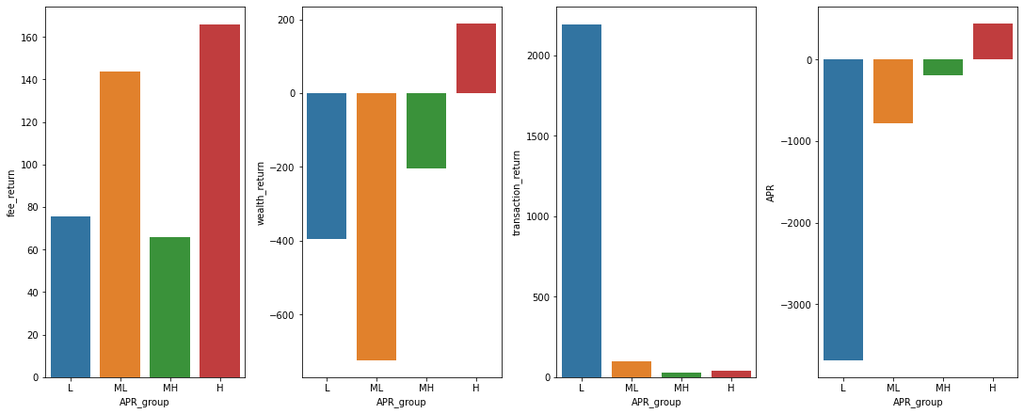

```python
median = LP.groupby(['APR_range'])[['fee_return','wealth_return','transaction_return','APR']].quantile(0.5)
median['APR_group'] = median.index
fig,axes=plt.subplots(1,4,constrained_layout=True,figsize=(15,6))
sns.barplot(x='APR_group',y='fee_return',data=median,ax=axes[0])
sns.barplot(x='APR_group',y='wealth_return',data=median,ax=axes[1])
sns.barplot(x='APR_group',y='transaction_return',data=median,ax=axes[2])
sns.barplot(x='APR_group',y='APR',data=median,ax=axes[3])
plt.show()
```

## Active LP

```python
cleared.groupby(['from'])['from'].count().describe().to_frame().T  ## 总体LP参与position数量
```

|  | count | mean | std | min | 25% | 50% | 75% | max |
| --- | --- | --- | --- | --- | --- | --- | --- | --- |
| from | 163.0 | 1.895706 | 2.159142 | 1.0 | 1.0 | 1.0 | 2.0 | 17.0 |

```python
A_LP = cleared.groupby(['from'])['from'].count()
A_LP[A_LP>5].shape
```

```
(9,)
```

```python
AMM = A_LP[A_LP>10].index
LP.loc[AMM,'APR'].quantile(0.9)
```

```
250.2641126799043
```

```python
AMM = A_LP[A_LP>10].index
LP.loc[AMM,'APR'].sort_values()[-20:]
```

```
from
0x46bcF9c0f0A59EdA5D2350Abb5d584c07cD61D0B   -208.356850
0x33CB9f2F86964dBbeFEff8867E70fBffE8a4eF00    301.221997
Name: APR, dtype: float64
```

```python
transaction['price_change'] = transaction['p_current'] - transaction.shift(1)['p_current']
transaction['p_previous'] = transaction.shift(1)['p_current']
transaction.loc[swap,'price_change'].describe().to_frame().T
```

|  | count | mean | std | min | 25% | 50% | 75% | max |
| --- | --- | --- | --- | --- | --- | --- | --- | --- |
| price_change | 6065.0 | 0.742805 | 53.479423 | -767.45679 | -13.455651 | 0.079946 | 15.755178 | 783.935656 |

## 交易量对价格变化的影响

swap导致的价格变动分布

```python
transaction.loc[swap,'price_change'].describe().to_frame().T
```

|  | count | mean | std | min | 25% | 50% | 75% | max |
| --- | --- | --- | --- | --- | --- | --- | --- | --- |
| price_change | 6065.0 | 0.742805 | 53.479423 | -767.45679 | -13.455651 | 0.079946 | 15.755178 | 783.935656 |

```python
transaction.loc[21610:21615,['event_name','amount0_delta','p_current','p_previous','price_change']]
```

|  | event_name | amount0_delta | p_current | p_previous | price_change |
| --- | --- | --- | --- | --- | --- |

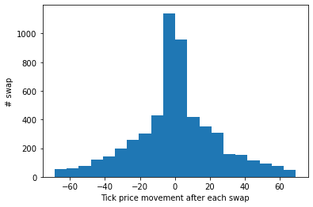

```python
plt.hist(transaction.loc[swap,'price_change'],bins=20,range=(transaction.loc[swap,'price_change'].quantile(0.05),transaction.loc[swap,'price_change'].quantile(0.95)))
plt.xlabel('Tick price movement after each swap')
plt.ylabel('# swap')
plt.show()
```

```python
transaction.loc[swap,'tick'].diff().abs().value_counts().to_frame('跨越tick数量百分比').T/len(swap)
```

|  | 1.0 | 0.0 | 2.0 | 3.0 | 5.0 | 4.0 | 6.0 | 7.0 | 10.0 | 13.0 | ... | 305.0 | 353.0 | 240.0 | 126.0 | 224.0 | 172.0 | 352.0 | 180.0 | 230.0 | 145.0 |
| --- | --- | --- | --- | --- | --- | --- | --- | --- | --- | --- | --- | --- | --- | --- | --- | --- | --- | --- | --- | --- | --- |
| 跨越tick数量百分比 | 0.080132 | 0.057873 | 0.053751 | 0.045012 | 0.035614 | 0.032811 | 0.030668 | 0.024732 | 0.023083 | 0.021599 | ... | 0.000165 | 0.000165 | 0.000165 | 0.000165 | 0.000165 | 0.000165 | 0.000165 | 0.000165 | 0.000165 | 0.000165 |

1 rows × 237 columns

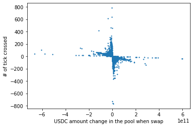

```python
plt.scatter(transaction.loc[swap,'amount0_delta'],transaction.loc[swap,'tick'].diff(),s=2)
plt.xlabel('USDC amount change in the pool when swap')
plt.ylabel('# of tick crossed')
plt.show()
```

USDC涨价时消耗USDC

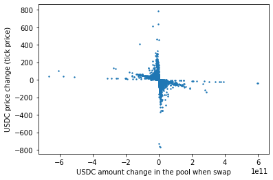

```python
plt.scatter(transaction.loc[swap,'amount0_delta'],transaction.loc[swap,'price_change'],s=2)
plt.xlabel('USDC amount change in the pool when swap')
plt.ylabel('USDC price change (tick price)')
```

斜率近似为流动性=>流动性一直在变化

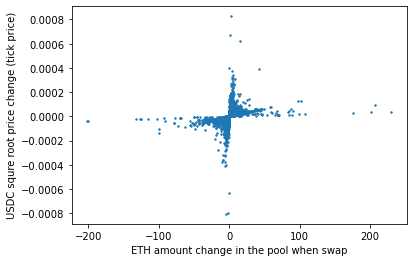

```python
transaction['p_squre_change'] = np.sqrt(1.0001**transaction['p_current']/10**12) - np.sqrt(1.0001**transaction['p_previous']/10**12)
plt.scatter(transaction.loc[swap,'amount1_delta'],transaction.loc[swap,'p_squre_change'],s=2)
plt.xlabel('ETH amount change in the pool when swap')
plt.ylabel('USDC squre root price change (tick price)')
```

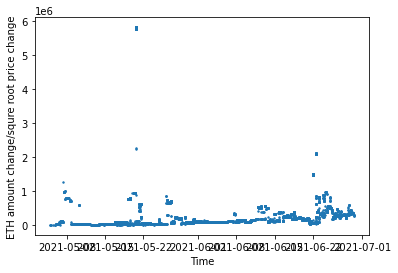

```python
L = transaction.loc[swap,'amount1_delta']/transaction.loc[swap,'p_squre_change']
plt.scatter(transaction.loc[swap,'timeStamp'],L,s=2)
plt.xlabel('Time')
plt.ylabel('ETH amount change/squre root price change')
```

swap导致的价格变动分布

```python
transaction.loc[swap,'price_change'].describe().to_frame().T ## 0.01%
```

|  | count | mean | std | min | 25% | 50% | 75% | max |
| --- | --- | --- | --- | --- | --- | --- | --- | --- |
| price_change | 6065.0 | 0.742805 | 53.479423 | -767.45679 | -13.455651 | 0.079946 | 15.755178 | 783.935656 |

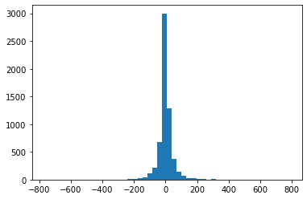

```python
plt.hist(transaction.loc[swap,'price_change'],bins=50)
plt.show()
```

## Liquidity distribution

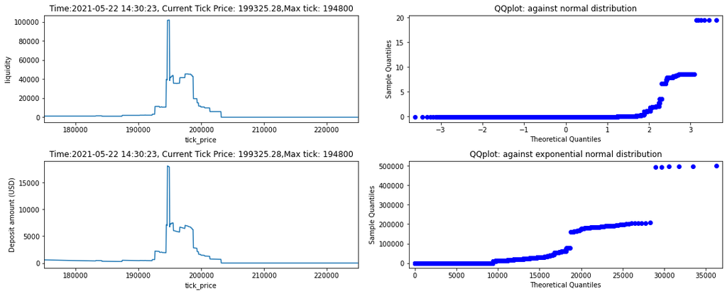

```python
tran = pd.read_csv(indir+'\\'+file,low_memory=False)
time_1 = 2000
LD1 = tran.loc[:time_1,['tickLower','tickUpper','event_name','liquidity_delta']]
time = datetime.fromtimestamp(tran.loc[time_1,'timeStamp'])
current = math.log(float(tran.loc[time_1,'sqrtPriceX96'])/2**96,1.0001)*2
del tran
LD1.drop(index = LD1[LD1['event_name'].isin(['Collect','Swap','Initialize'])].index,inplace=True)
LD1['liquidity_delta'] = LD1['liquidity_delta'].apply(lambda x:int(x)/10**12)
LD1_position = LD1.groupby(['tickLower','tickUpper'])['liquidity_delta'].sum().to_frame()
LD1_position['tickLower'] = LD1_position.index.map(lambda x:x[0])
LD1_position['tickUpper'] = LD1_position.index.map(lambda x:x[1])
LD1_position.drop(index=LD1_position[LD1_position['liquidity_delta']==0].index)
LD1_liquidity = pd.DataFrame(index=range(int(LD1_position['tickLower'].min()),int(LD1_position['tickUpper'].max()),60))
LD1_liquidity['liquidity']=0
for row in LD1_position.values:
    L,low,upper = row
    LD1_liquidity.loc[int(low):int(upper)-60,'liquidity'] = L + LD1_liquidity.loc[int(low):int(upper)-60,'liquidity']
m_price = LD1_liquidity.index[LD1_liquidity['liquidity'].argmax()]
fig,axes = plt.subplots(2,2,constrained_layout=True,figsize=(15,6))
axes[0][0].plot(LD1_liquidity)
axes[0][0].set_xlabel('tick_price')
axes[0][0].set_ylabel('liquidity')
axes[0][0].set_xlim([175000,225000])
axes[0][0].set_title('Time:{}, Current Tick Price: {:.2f},Max tick: {}'.format(time,current,m_price))
sm.qqplot(LD1_liquidity['liquidity'].values,fit=True,ax=axes[0][1])
axes[0][1].set_title('QQplot: against normal distribution'.format(time,current,m_price))
USDC_amount = LD1_liquidity.reset_index()
def cal_deposit(x):
    tick_low,L = x
    if tick_low>current:
        return L*(1/math.sqrt(1.0001**(tick_low)/10**12)-1/math.sqrt(1.0001**(tick_low+60)/10**12))
    else:
        return L*(math.sqrt(1.0001**(tick_low+60)/10**12)-math.sqrt(1.0001**(tick_low)/10**12))/(1.0001**(tick_low+30)/10**12)
USDC_amount['USDC'] = USDC_amount.apply(lambda x:cal_deposit(x),axis=1)
axes[1][0].plot(USDC_amount['index'],USDC_amount['USDC'])
axes[1][0].set_xlabel('tick_price')
axes[1][0].set_ylabel('Deposit amount (USD)')
axes[1][0].set_xlim([175000,225000])
axes[1][0].set_title('Time:{}, Current Tick Price: {:.2f},Max tick: {}'.format(time,current,m_price))
sm.qqplot(USDC_amount['USDC'].values,stats.exponnorm,fit=True,ax=axes[1][1])
axes[1][1].set_title('QQplot: against exponential normal distribution'.format(time,current,m_price))
```

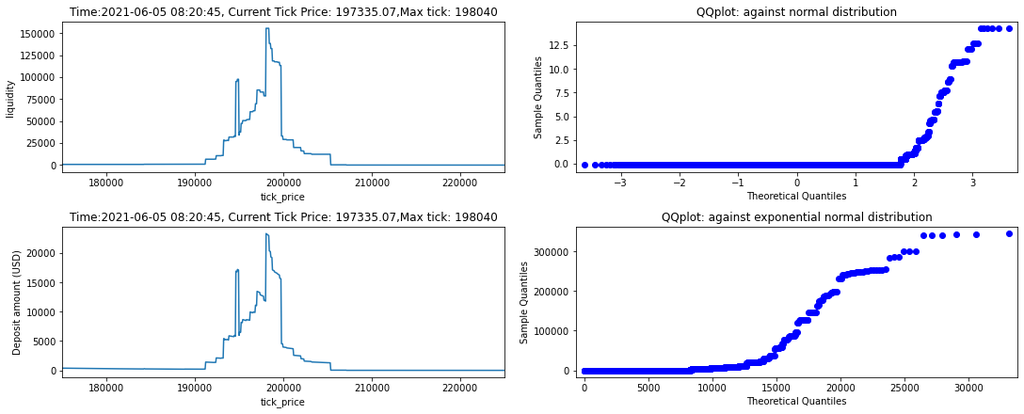

```python
tran = pd.read_csv(indir+'\\'+file,low_memory=False)
time_1 = 4000
LD1 = tran.loc[:time_1,['tickLower','tickUpper','event_name','liquidity_delta']]
time = datetime.fromtimestamp(tran.loc[time_1,'timeStamp'])
current = math.log(float(tran.loc[time_1,'sqrtPriceX96'])/2**96,1.0001)*2
del tran
LD1.drop(index = LD1[LD1['event_name'].isin(['Collect','Swap','Initialize'])].index,inplace=True)
LD1['liquidity_delta'] = LD1['liquidity_delta'].apply(lambda x:int(x)/10**12)
LD1_position = LD1.groupby(['tickLower','tickUpper'])['liquidity_delta'].sum().to_frame()
LD1_position['tickLower'] = LD1_position.index.map(lambda x:x[0])
LD1_position['tickUpper'] = LD1_position.index.map(lambda x:x[1])
LD1_position.drop(index=LD1_position[LD1_position['liquidity_delta']==0].index)
LD1_liquidity = pd.DataFrame(index=range(int(LD1_position['tickLower'].min()),int(LD1_position['tickUpper'].max()),60))
LD1_liquidity['liquidity']=0
for row in LD1_position.values:
    L,low,upper = row
    LD1_liquidity.loc[int(low):int(upper)-60,'liquidity'] = L + LD1_liquidity.loc[int(low):int(upper)-60,'liquidity']
m_price = LD1_liquidity.index[LD1_liquidity['liquidity'].argmax()]
fig,axes = plt.subplots(2,2,constrained_layout=True,figsize=(15,6))
axes[0][0].plot(LD1_liquidity)
axes[0][0].set_xlabel('tick_price')
axes[0][0].set_ylabel('liquidity ')
axes[0][0].set_xlim([175000,225000])
axes[0][0].set_title('Time:{}, Current Tick Price: {:.2f},Max tick: {}'.format(time,current,m_price))
sm.qqplot(LD1_liquidity['liquidity'].values,fit=True,ax=axes[0][1])
axes[0][1].set_title('QQplot: against normal distribution'.format(time,current,m_price))
USDC_amount = LD1_liquidity.reset_index()
def cal_deposit(x):
    tick_low,L = x
    if tick_low>current:
        return L*(1/math.sqrt(1.0001**(tick_low)/10**12)-1/math.sqrt(1.0001**(tick_low+60)/10**12))
    else:
        return L*(math.sqrt(1.0001**(tick_low+60)/10**12)-math.sqrt(1.0001**(tick_low)/10**12))/(1.0001**(tick_low+30)/10**12)
USDC_amount['USDC'] = USDC_amount.apply(lambda x:cal_deposit(x),axis=1)
axes[1][0].plot(USDC_amount['index'],USDC_amount['USDC'])
axes[1][0].set_xlabel('tick_price')
axes[1][0].set_ylabel('Deposit amount (USD)')
axes[1][0].set_xlim([175000,225000])
axes[1][0].set_title('Time:{}, Current Tick Price: {:.2f},Max tick: {}'.format(time,current,m_price))
sm.qqplot(USDC_amount['USDC'].values,stats.exponnorm,fit=True,ax=axes[1][1])
axes[1][1].set_title('QQplot: against exponential normal distribution'.format(time,current,m_price))
```

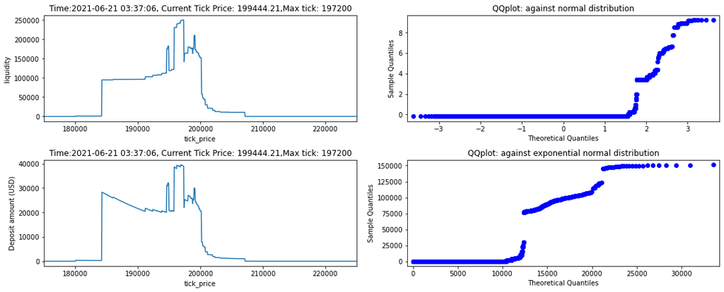

```python
tran = pd.read_csv(indir+'\\'+file,low_memory=False)
time_1 = 6000
LD1 = tran.loc[:time_1,['tickLower','tickUpper','event_name','liquidity_delta']]
time = datetime.fromtimestamp(tran.loc[time_1,'timeStamp'])
current = math.log(float(tran.loc[time_1,'sqrtPriceX96'])/2**96,1.0001)*2
del tran
LD1.drop(index = LD1[LD1['event_name'].isin(['Collect','Swap','Initialize'])].index,inplace=True)
LD1['liquidity_delta'] = LD1['liquidity_delta'].apply(lambda x:int(x)/10**12)
LD1_position = LD1.groupby(['tickLower','tickUpper'])['liquidity_delta'].sum().to_frame()
LD1_position['tickLower'] = LD1_position.index.map(lambda x:x[0])
LD1_position['tickUpper'] = LD1_position.index.map(lambda x:x[1])
LD1_position.drop(index=LD1_position[LD1_position['liquidity_delta']==0].index)
LD1_liquidity = pd.DataFrame(index=range(int(LD1_position['tickLower'].min()),int(LD1_position['tickUpper'].max()),60))
LD1_liquidity['liquidity']=0
for row in LD1_position.values:
    L,low,upper = row
    LD1_liquidity.loc[int(low):int(upper)-60,'liquidity'] = L + LD1_liquidity.loc[int(low):int(upper)-60,'liquidity']
m_price = LD1_liquidity.index[LD1_liquidity['liquidity'].argmax()]
fig,axes = plt.subplots(2,2,constrained_layout=True,figsize=(15,6))
axes[0][0].plot(LD1_liquidity)
axes[0][0].set_xlabel('tick_price')
axes[0][0].set_ylabel('liquidity ')
axes[0][0].set_xlim([175000,225000])
axes[0][0].set_title('Time:{}, Current Tick Price: {:.2f},Max tick: {}'.format(time,current,m_price))
sm.qqplot(LD1_liquidity['liquidity'].values,fit=True,ax=axes[0][1])
axes[0][1].set_title('QQplot: against normal distribution'.format(time,current,m_price))
USDC_amount = LD1_liquidity.reset_index()
def cal_deposit(x):
    tick_low,L = x
    if tick_low>current:
        return L*(1/math.sqrt(1.0001**(tick_low)/10**12)-1/math.sqrt(1.0001**(tick_low+60)/10**12))
    else:
        return L*(math.sqrt(1.0001**(tick_low+60)/10**12)-math.sqrt(1.0001**(tick_low)/10**12))/(1.0001**(tick_low+30)/10**12)
USDC_amount['USDC'] = USDC_amount.apply(lambda x:cal_deposit(x),axis=1)
axes[1][0].plot(USDC_amount['index'],USDC_amount['USDC'])
axes[1][0].set_xlabel('tick_price')
axes[1][0].set_ylabel('Deposit amount (USD)')
axes[1][0].set_xlim([175000,225000])
axes[1][0].set_title('Time:{}, Current Tick Price: {:.2f},Max tick: {}'.format(time,current,m_price))
sm.qqplot(USDC_amount['USDC'].values,stats.exponnorm,fit=True,ax=axes[1][1])
axes[1][1].set_title('QQplot: against exponential normal distribution'.format(time,current,m_price))
```

```python
stats.exponnorm.fit(LD1_liquidity['liquidity']) ## exponentially modified Normal distribution：mu,lambda,sigma
```

```
(3329.3438127291693, -5.6919414034621525, 1.5843286105002634)
```

```python
stats.logistic.fit(LD1_liquidity['liquidity'])## logistics distribution：mu,sigma
```

```
(645.4867820789312, 5213.485677541152)
```